# STAT 571/701 Modern Data Mining, HW 2

Alex Coble

Joe Moran

February 27, 2021

# Overview

Principal Component Analysis is widely used in data exploration, dimension reduction, data visualization. The aim is to transform original data into uncorrelated linear combinations of the original data while keeping the information contained in the data. High dimensional data tends to show clusters in lower dimensional view.

Clustering Analysis is another form of EDA. Here we are hoping to group data points which are close to each other within the groups and far away between different groups. Clustering using PC’s can be effective. Clustering analysis can be very subjective in the way we need to summarize the properties within each group.

Both PCA and Clustering Analysis are so called unsupervised learning. There is no response variables involved in the process.

For supervised learning, we try to find out how does a set of predictors relate to some response variable of the interest. Multiple regression is still by far, one of the most popular methods. We use linear models as a working model for its simplicity and interpretability. It is important that we use domain knowledge as much as we can to determine the form of the response as well as the function format of the factors.

## 0.1 Objectives

- PCA
- SVD
- Clustering Analysis
- Linear Regression

## 0.2 Review materials

- Study Module 2: PCA
- Study Module 3: Clustering Analysis
- Study lecture 4: Multiple regression

# 1 Case study 1: Self-seteem

Self-esteem generally describes a person’s overall sense of self-worthiness and personal value. It can play significant role in one’s motivation and success throughout the life. Factors that influence self-esteem can be inner thinking, health condition, age, life experiences etc. We will try to identify possible factors in our data that are related to the level of self-esteem.

In the well-cited National Longitudinal Study of Youth (NLSY79), it follows about 13,000 individuals and numerous individual-year information has been gathered through surveys. The survey data is open to public [here](https://www.nlsinfo.org/investigator/). Among many variables we assembled a subset of variables including personal demographic variables in different years, household environment in 79, ASVAB test Scores in 81 and Self-Esteem scores in 81 and 87 respectively.

The data is store in `NLSY79.csv`.

Here are the description of variables:

**Personal Demographic Variables**

- Gender: a factor with levels “female” and “male”
- Education05: years of education completed by 2005
- HeightFeet05, HeightInch05: height measurement. For example, a person of 5’10 will be recorded as HeightFeet05=5, HeightInch05=10.
- Weight05: weight in lbs.
- Income87, Income05: total annual income from wages and salary in 2005.
- Job87, Job05: job type in 1987 and 2005, including Protective Service Occupations, Food Preparation and Serving Related Occupations, Cleaning and Building Service Occupations, Entertainment Attendants and Related Workers, Funeral Related Occupations, Personal Care and Service Workers, Sales and Related Workers, Office and Administrative Support Workers, Farming, Fishing and Forestry Occupations, Construction Trade and Extraction Workers, Installation, Maintenance and Repairs Workers, Production and Operating Workers, Food Preparation Occupations, Setters, Operators and Tenders, Transportation and Material Moving Workers

**Household Environment**

- Imagazine: a variable taking on the value 1 if anyone in the respondent’s household regularly read magazines in 1979, otherwise 0
- Inewspaper: a variable taking on the value 1 if anyone in the respondent’s household regularly read newspapers in 1979, otherwise 0
- Ilibrary: a variable taking on the value 1 if anyone in the respondent’s household had a library card in 1979, otherwise 0
- MotherEd: mother’s years of education
- FatherEd: father’s years of education
- FamilyIncome78

**Variables Related to ASVAB test Scores in 1981**

| Test | Description |
| --- | --- |
| AFQT | percentile score on the AFQT intelligence test in 1981 |
| Coding | score on the Coding Speed test in 1981 |
| Auto | score on the Automotive and Shop test in 1981 |
| Mechanic | score on the Mechanic test in 1981 |
| Elec | score on the Electronics Information test in 1981 |
| Science | score on the General Science test in 1981 |
| Math | score on the Math test in 1981 |
| Arith | score on the Arithmetic Reasoning test in 1981 |
| Word | score on the Word Knowledge Test in 1981 |
| Parag | score on the Paragraph Comprehension test in 1981 |
| Numer | score on the Numerical Operations test in 1981 |

**Self-Esteem test 81 and 87**

We have two sets of self-esteem test, one in 1981 and the other in 1987. Each set has same 10 questions. They are labeled as `Esteem81` and `Esteem87` respectively followed by the question number. For example, `Esteem81_1` is Esteem question 1 in 81.

The following 10 questions are answered as 1: strongly agree, 2: agree, 3: disagree, 4: strongly disagree

- Esteem 1: “I am a person of worth”
- Esteem 2: “I have a number of good qualities”
- Esteem 3: “I am inclined to feel like a failure”
- Esteem 4: “I do things as well as others”
- Esteem 5: “I do not have much to be proud of”
- Esteem 6: “I take a positive attitude towards myself and others”
- Esteem 7: “I am satisfied with myself”
- Esteem 8: “I wish I could have more respect for myself”
- Esteem 9: “I feel useless at times”
- Esteem 10: “I think I am no good at all”

## 1.1 Data preparation

Load the data. Do a quick EDA to get familiar with the data set. Pay attention to the unit of each variable. Are there any missing values?

**Response:** We will use the package `skimr` to summarize the NLSY79 data:

```r
Question_1_raw <- read.csv("data/NLSY79.csv")

skim(Question_1_raw)
```

Data summary

| Name | Question_1_raw |
| --- | --- |
| Number of rows | 2431 |
| Number of columns | 46 |
| _______________________ |  |
| Column type frequency: |  |
| character | 2 |
| numeric | 44 |
| ________________________ |  |
| Group variables | None |

**Variable type: character**

| skim_variable | n_missing | complete_rate | min | max | empty | n_unique | whitespace |
| --- | --- | --- | --- | --- | --- | --- | --- |
| Gender | 0 | 1 | 4 | 6 | 0 | 2 | 0 |
| Job05 | 0 | 1 | 0 | 83 | 56 | 31 | 0 |

**Variable type: numeric**

| skim_variable | n_missing | complete_rate | mean | sd | p0 | p25 | p50 | p75 | p100 | hist |
| --- | --- | --- | --- | --- | --- | --- | --- | --- | --- | --- |
| Subject | 0 | 1 | 3504.50 | 2764.82 | 2 | 1592.5 | 3137 | 4668.5 | 12140 | ▇▇▃▁▂ |
| Education05 | 0 | 1 | 13.91 | 2.50 | 6 | 12.0 | 13 | 16.0 | 20 | ▁▁▇▃▂ |
| Income87 | 0 | 1 | 13398.80 | 11599.62 | -2 | 4500.0 | 12000 | 19000.0 | 59387 | ▇▆▂▁▁ |
| Income05 | 0 | 1 | 49414.80 | 46287.60 | 63 | 22650.0 | 38500 | 61350.0 | 703637 | ▇▁▁▁▁ |
| Weight05 | 0 | 1 | 183.10 | 41.71 | 81 | 150.0 | 180 | 209.0 | 380 | ▂▇▃▁▁ |
| HeightFeet05 | 0 | 1 | 5.18 | 0.57 | -4 | 5.0 | 5 | 5.0 | 8 | ▁▁▁▇▂ |
| HeightInch05 | 0 | 1 | 5.32 | 3.51 | 0 | 2.0 | 5 | 8.0 | 11 | ▇▅▅▅▇ |
| Imagazine | 0 | 1 | 0.72 | 0.45 | 0 | 0.0 | 1 | 1.0 | 1 | ▃▁▁▁▇ |
| Inewspaper | 0 | 1 | 0.86 | 0.35 | 0 | 1.0 | 1 | 1.0 | 1 | ▁▁▁▁▇ |
| Ilibrary | 0 | 1 | 0.77 | 0.42 | 0 | 1.0 | 1 | 1.0 | 1 | ▂▁▁▁▇ |
| MotherEd | 0 | 1 | 11.70 | 2.61 | 0 | 11.0 | 12 | 12.0 | 20 | ▁▁▇▂▁ |
| FatherEd | 0 | 1 | 11.85 | 3.56 | 0 | 10.0 | 12 | 14.0 | 20 | ▁▂▇▃▁ |
| FamilyIncome78 | 0 | 1 | 21251.67 | 13878.56 | 0 | 11167.0 | 20000 | 27500.0 | 75001 | ▇▇▂▁▁ |
| Science | 0 | 1 | 16.29 | 4.77 | 0 | 13.0 | 17 | 20.0 | 25 | ▁▂▆▇▅ |
| Arith | 0 | 1 | 18.59 | 7.15 | 0 | 13.0 | 19 | 25.0 | 30 | ▁▆▇▇▇ |
| Word | 0 | 1 | 26.61 | 7.02 | 0 | 23.0 | 28 | 32.0 | 35 | ▁▁▂▅▇ |
| Parag | 0 | 1 | 11.23 | 3.15 | 0 | 10.0 | 12 | 14.0 | 15 | ▁▂▂▆▇ |
| Number | 0 | 1 | 35.46 | 10.11 | 0 | 29.0 | 36 | 44.0 | 50 | ▁▂▅▇▇ |
| Coding | 0 | 1 | 47.05 | 15.24 | 0 | 38.0 | 48 | 57.0 | 84 | ▁▃▇▇▂ |
| Auto | 0 | 1 | 14.26 | 5.32 | 0 | 10.0 | 14 | 18.0 | 25 | ▁▆▇▆▅ |
| Math | 0 | 1 | 14.26 | 6.29 | 0 | 9.0 | 14 | 20.0 | 25 | ▂▇▇▆▇ |
| Mechanic | 0 | 1 | 14.43 | 5.10 | 0 | 11.0 | 14 | 18.0 | 25 | ▁▅▇▆▃ |
| Elec | 0 | 1 | 11.59 | 4.09 | 0 | 9.0 | 12 | 15.0 | 20 | ▁▅▇▇▃ |
| AFQT | 0 | 1 | 54.68 | 27.70 | 0 | 31.9 | 57 | 78.2 | 100 | ▅▆▇▇▇ |
| Esteem81_1 | 0 | 1 | 1.42 | 0.52 | 1 | 1.0 | 1 | 2.0 | 4 | ▇▆▁▁▁ |
| Esteem81_2 | 0 | 1 | 1.42 | 0.51 | 1 | 1.0 | 1 | 2.0 | 4 | ▇▆▁▁▁ |
| Esteem81_3 | 0 | 1 | 3.51 | 0.57 | 1 | 3.0 | 4 | 4.0 | 4 | ▁▁▁▆▇ |
| Esteem81_4 | 0 | 1 | 1.57 | 0.56 | 1 | 1.0 | 2 | 2.0 | 4 | ▇▇▁▁▁ |
| Esteem81_5 | 0 | 1 | 3.46 | 0.65 | 1 | 3.0 | 4 | 4.0 | 4 | ▁▁▁▆▇ |
| Esteem81_6 | 0 | 1 | 1.62 | 0.56 | 1 | 1.0 | 2 | 2.0 | 4 | ▆▇▁▁▁ |
| Esteem81_7 | 0 | 1 | 1.75 | 0.60 | 1 | 1.0 | 2 | 2.0 | 4 | ▅▇▁▁▁ |
| Esteem81_8 | 0 | 1 | 3.13 | 0.76 | 1 | 3.0 | 3 | 4.0 | 4 | ▁▂▁▇▆ |
| Esteem81_9 | 0 | 1 | 3.16 | 0.72 | 1 | 3.0 | 3 | 4.0 | 4 | ▁▂▁▇▆ |
| Esteem81_10 | 0 | 1 | 3.40 | 0.66 | 1 | 3.0 | 3 | 4.0 | 4 | ▁▁▁▇▇ |
| Esteem87_1 | 0 | 1 | 1.38 | 0.50 | 1 | 1.0 | 1 | 2.0 | 4 | ▇▅▁▁▁ |
| Esteem87_2 | 0 | 1 | 1.40 | 0.50 | 1 | 1.0 | 1 | 2.0 | 4 | ▇▅▁▁▁ |
| Esteem87_3 | 0 | 1 | 3.58 | 0.54 | 1 | 3.0 | 4 | 4.0 | 4 | ▁▁▁▅▇ |
| Esteem87_4 | 0 | 1 | 1.50 | 0.53 | 1 | 1.0 | 1 | 2.0 | 4 | ▇▇▁▁▁ |
| Esteem87_5 | 0 | 1 | 3.53 | 0.60 | 1 | 3.0 | 4 | 4.0 | 4 | ▁▁▁▆▇ |
| Esteem87_6 | 0 | 1 | 1.59 | 0.56 | 1 | 1.0 | 2 | 2.0 | 4 | ▆▇▁▁▁ |
| Esteem87_7 | 0 | 1 | 1.72 | 0.58 | 1 | 1.0 | 2 | 2.0 | 4 | ▅▇▁▁▁ |
| Esteem87_8 | 0 | 1 | 3.10 | 0.74 | 1 | 3.0 | 3 | 4.0 | 4 | ▁▃▁▇▅ |
| Esteem87_9 | 0 | 1 | 3.06 | 0.74 | 1 | 3.0 | 3 | 4.0 | 4 | ▁▃▁▇▅ |
| Esteem87_10 | 0 | 1 | 3.37 | 0.65 | 1 | 3.0 | 3 | 4.0 | 4 | ▁▁▁▇▇ |

It is clear that there are missing values (coded as variables less than 0) for `Income87` and `HeightFeet05`. Per review of the NLSY79 data guide, any missing values were coded as -1 through -5; therefore, these observations represent missing values. Note that there are only a small number (26 for `Income87` and 4 for `HeightFeet05`) and the observations with missing values do not seem to be unique or correlated in any way. Since the built-in PCA functionality in R will not work with missing values, we will drop them, although we do not expect this to bias our results. In addition, there are 56 observations with blank values for `Job05`; the missing values do not appear unique in any way. Again, we will drop them, although we do not expect this to bias our results.

## 1.2 Self esteem evaluation

Let concentrate on Esteem scores evaluated in 87.

1. Reverse Esteem 1, 2, 4, 6, and 7 so that a higher score corresponds to higher self-esteem. (Hint: if we store the esteem data in `data.esteem`, then `data.esteem[, c(1, 2, 4, 6, 7)] <- 5 - data.esteem[, c(1, 2, 4, 6, 7)]` to reverse the score.)

**Response:** We create a new dataset `Esteem_Data` with the variables to be corrected, use the correction method noted above, and join the corrected variables back into `Question_1_clean`.

```r
# Create working version of raw data and assign row names.
Question_1_clean <- Question_1_raw
rownames(Question_1_clean) <-  paste("p", seq(1:nrow(Question_1_clean)), sep="")

# Drop missing values.
Question_1_clean <- Question_1_clean %>%
  filter(Income87 >= 0) %>%
  filter(HeightFeet05 >= 0) %>%
  filter(Job05 != "")

# Subset data to only include esteem measures to be reversed.
Esteem_Data <- Question_1_clean %>%
  select(Subject,Esteem81_1,Esteem81_2,Esteem81_4,Esteem81_6,Esteem81_7,Esteem87_1,Esteem87_2,Esteem87_4,Esteem87_6,Esteem87_7)

# Reverse scale of esteem measures 1, 2, 4, 6, 7.
Esteem_Data[,c(2,3,4,5,6,7,8,9,10,11)] <- 5 - Esteem_Data[,c(2,3,4,5,6,7,8,9,10,11)]

# Remove uncorrected variables from master dataset.
Question_1_clean <- Question_1_clean %>%
  select(-Esteem81_1,-Esteem81_2,-Esteem81_4,-Esteem81_6,-Esteem81_7,-Esteem87_1,-Esteem87_2,-Esteem87_4,-Esteem87_6,-Esteem87_7)

# Merge in corrected variables to master dataset.
Question_1_clean <- inner_join(Question_1_clean,Esteem_Data,by = "Subject")
```

2. Write a brief summary with necessary plots about the 10 esteem measurements.

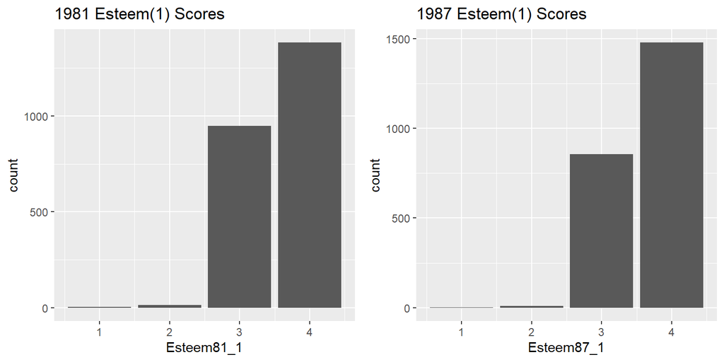

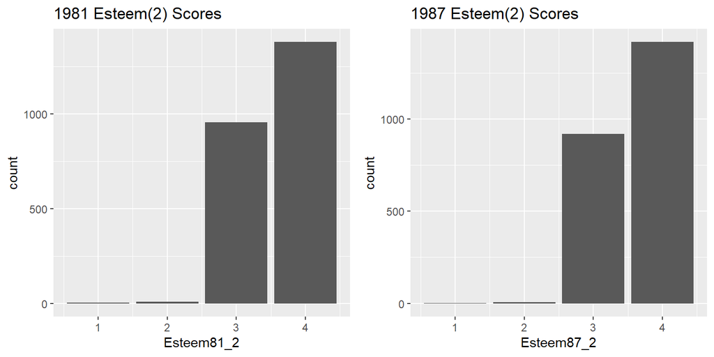

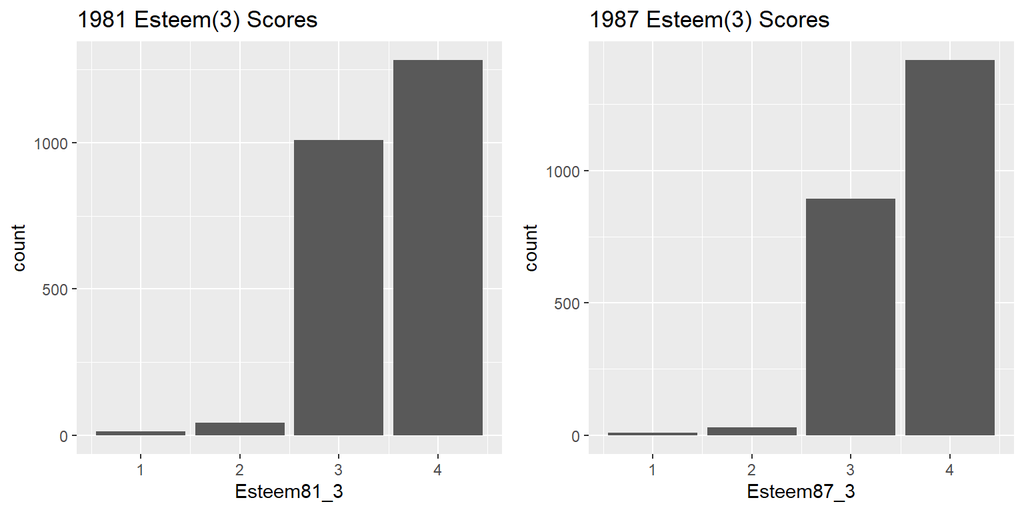

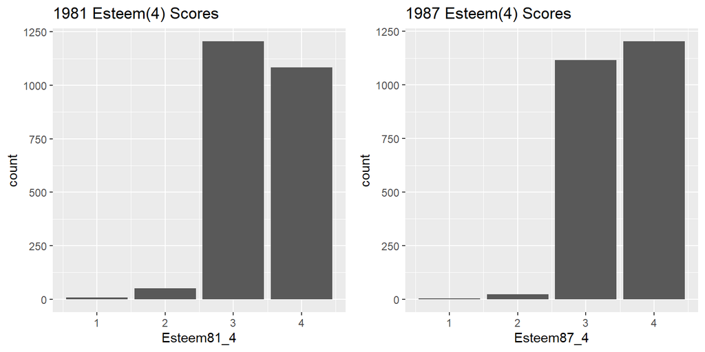

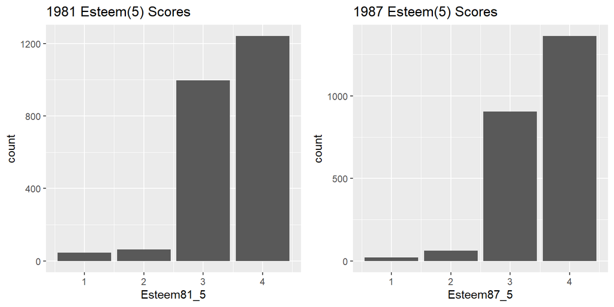

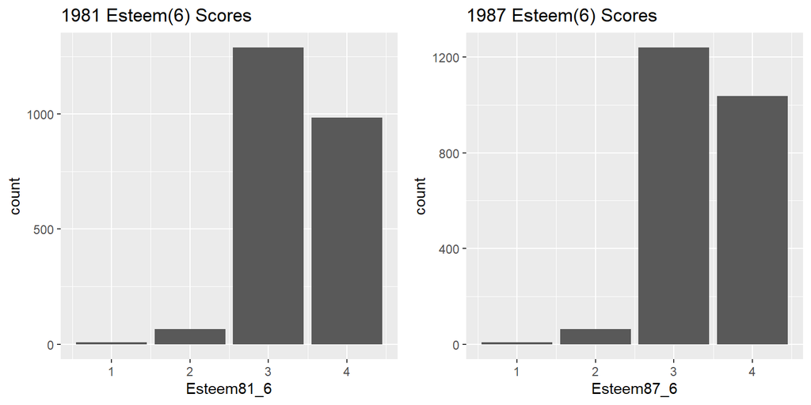

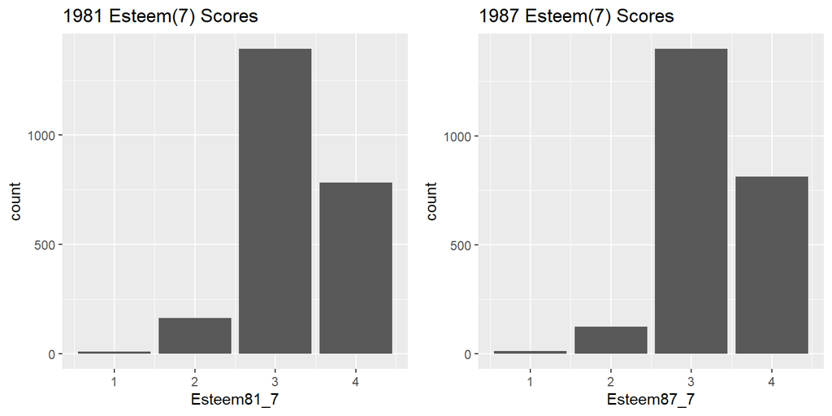

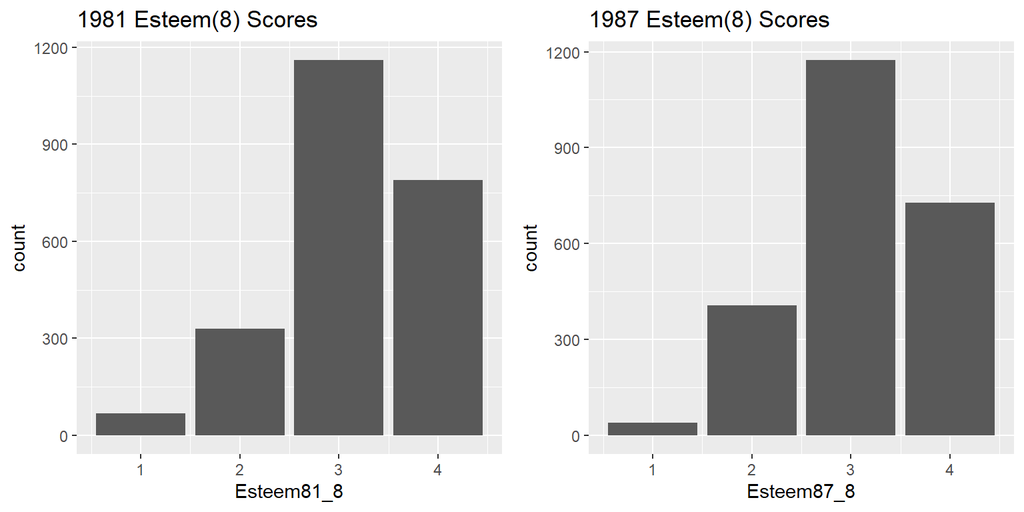

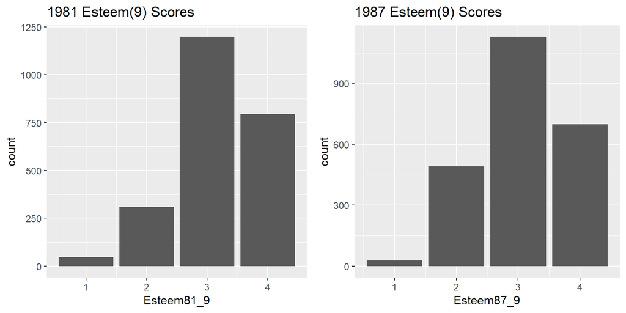

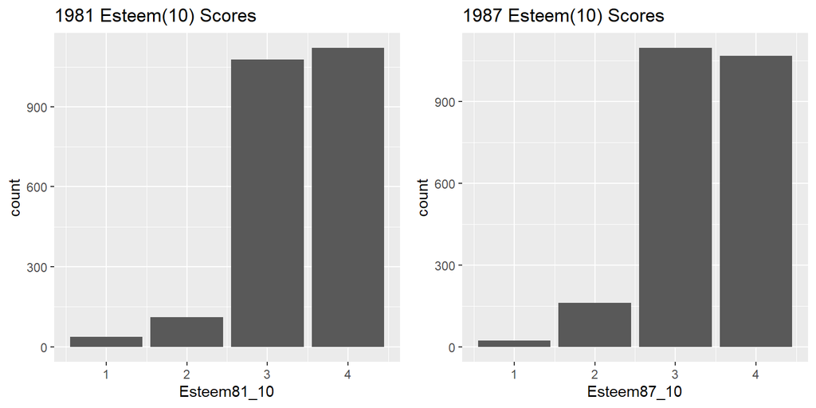

```r
# Combine plots generated above.
Question_1_Plots_Combined <- ggpubr::ggarrange(plot_81_1,plot_87_1,plot_81_2,plot_87_2,plot_81_3,plot_87_3,plot_81_4,plot_87_4,plot_81_5,plot_87_5,plot_81_6,plot_87_6,plot_81_7,plot_87_7,plot_81_8,plot_87_8,plot_81_9,plot_87_9,plot_81_10,plot_87_10,ncol = 2)

Question_1_Plots_Combined
```

3. Do esteem scores all positively correlated? Report the pairwise correlation table and write a brief summary.

```r
# Subset data to 1987 esteem variables only.
Esteem_Data_1987 <- Question_1_clean %>%
  select(Esteem87_1,Esteem87_2,Esteem87_3,Esteem87_4,Esteem87_5,Esteem87_6,Esteem87_7,Esteem87_8,Esteem87_9,Esteem87_10)

# Report pairwise correlation table.
cor(Esteem_Data_1987)
```

```
##             Esteem87_1 Esteem87_2 Esteem87_3 Esteem87_4 Esteem87_5 Esteem87_6
## Esteem87_1       1.000      0.700      0.449      0.521      0.409      0.463
## Esteem87_2       0.700      1.000      0.442      0.545      0.408      0.484
## Esteem87_3       0.449      0.442      1.000      0.406      0.561      0.414
## Esteem87_4       0.521      0.545      0.406      1.000      0.385      0.509
## Esteem87_5       0.409      0.408      0.561      0.385      1.000      0.409
## Esteem87_6       0.463      0.484      0.414      0.509      0.409      1.000
## Esteem87_7       0.373      0.411      0.342      0.424      0.378      0.605
## Esteem87_8       0.270      0.286      0.348      0.299      0.383      0.408
## Esteem87_9       0.239      0.263      0.350      0.284      0.359      0.369
## Esteem87_10      0.310      0.329      0.463      0.360      0.437      0.443
##             Esteem87_7 Esteem87_8 Esteem87_9 Esteem87_10
## Esteem87_1       0.373      0.270      0.239       0.310
## Esteem87_2       0.411      0.286      0.263       0.329
## Esteem87_3       0.342      0.348      0.350       0.463
## Esteem87_4       0.424      0.299      0.284       0.360
## Esteem87_5       0.378      0.383      0.359       0.437
## Esteem87_6       0.605      0.408      0.369       0.443
## Esteem87_7       1.000      0.393      0.355       0.391
## Esteem87_8       0.393      1.000      0.436       0.442
## Esteem87_9       0.355      0.436      1.000       0.579
## Esteem87_10      0.391      0.442      0.579       1.000
```

4. PCA on 10 esteem measurements. (centered but no scaling)

**Response:** We first center the esteem measurements for 1987 and then perform principal component analysis on them.

```r
# Subset data to only include 1987 esteem measures.
Esteem_Data_1987 <- Question_1_clean %>%
  select(Esteem87_1,Esteem87_2,Esteem87_3,Esteem87_4,Esteem87_5,Esteem87_6,Esteem87_7,Esteem87_8,Esteem87_9,Esteem87_10)

# Center 1987 esteem measures and drop uncentered measures.
Esteem_Data_1987_centered <- Esteem_Data_1987 %>%
  mutate(Esteem87_1_Centered = Esteem87_1 - mean(Esteem87_1),
         Esteem87_2_Centered = Esteem87_2 - mean(Esteem87_2),
         Esteem87_3_Centered = Esteem87_3 - mean(Esteem87_3),
         Esteem87_4_Centered = Esteem87_4 - mean(Esteem87_4),
         Esteem87_5_Centered = Esteem87_5 - mean(Esteem87_5),
         Esteem87_6_Centered = Esteem87_6 - mean(Esteem87_6),
         Esteem87_7_Centered = Esteem87_7 - mean(Esteem87_7),
         Esteem87_8_Centered = Esteem87_8 - mean(Esteem87_8),
         Esteem87_9_Centered = Esteem87_9 - mean(Esteem87_9),
         Esteem87_10_Centered = Esteem87_10 - mean(Esteem87_10)) %>%
  select(Esteem87_1_Centered,Esteem87_2_Centered,Esteem87_3_Centered,Esteem87_4_Centered,Esteem87_5_Centered,Esteem87_6_Centered,Esteem87_7_Centered,Esteem87_8_Centered,Esteem87_9_Centered,Esteem87_10_Centered)

# Convert to dataframe.
Esteem_Data_1987_centered <- as.data.frame(Esteem_Data_1987_centered)

# Run PCA on 1987 centered esteem measures.
esteem_PCA <- prcomp(Esteem_Data_1987_centered,scale. = FALSE)
```

1. Report the PC1 and PC2 loadings.

**Response:** Below we report the loadings for the first two principal components of the 1987 esteem data.

```r
# Report loadings of PC1 and PC2.
esteem_PCA$rotation[,c(1,2)]
```

```
##                        PC1    PC2
## Esteem87_1_Centered  0.232 -0.371
## Esteem87_2_Centered  0.243 -0.364
## Esteem87_3_Centered  0.278 -0.156
## Esteem87_4_Centered  0.258 -0.320
## Esteem87_5_Centered  0.312 -0.143
## Esteem87_6_Centered  0.313 -0.211
## Esteem87_7_Centered  0.301 -0.164
## Esteem87_8_Centered  0.393  0.330
## Esteem87_9_Centered  0.402  0.578
## Esteem87_10_Centered 0.377  0.260
```

Are they unit vectors?

**Response:** To check that the length of the first two principal component vectors is 1, we report the Euclidean distances of the PC1 and PC2 vectors. They are both equal to one, indicating that both are unit vectors.

```r
colSums((esteem_PCA$rotation[,c(1,2)])^2)
```

```
## PC1 PC2
##   1   1
```

Are they uncorrelated?

**Response:** Below we report the pairwise correlation table for PC1 and PC2. As expected, the pairwise correlations are zero between PC1 and PC2.

```r
round(cor(esteem_PCA$x[,c(1,2)]),4)
```

```
##     PC1 PC2
## PC1   1   0
## PC2   0   1
```

2. Are there good interpretations for PC1 and PC2? (If loadings are all negative, take the positive loadings for the ease of interpretation)

**Response:** PC1 is approximately proportional to the sum of all 10 esteem measures, with some small differences in weight between the measures. PC2 is proportional to the difference between esteem measures 1 through 7 and the esteem measures 8 through 10.

3. How is the PC1 score obtained for each subject? Write down the formula.

4. Are PC1 scores and PC2 scores in the data uncorrelated?

**Response:** Note that the pairwise correlation table above relies on the aggregate correlation within the PC scores data; however, another check to ensure PC1 and PC2 are uncorrelated is that they are orthogonal. To check that they are orthogonal, we verify that their product is equal to zero:

```r
round(colSums(t(esteem_PCA$x[,1]) %*% esteem_PCA$x[,2]),4)
```

```
## [1] 0
```

5. Plot PVE (Proportion of Variance Explained) and summarize the plot.

**Response:** Below is a plot of PVE for the 10 principal components. It is clear that the first principal component explains a large proportion of the variance; using the “elbow rule”, we can elect to keep the first two principal components.

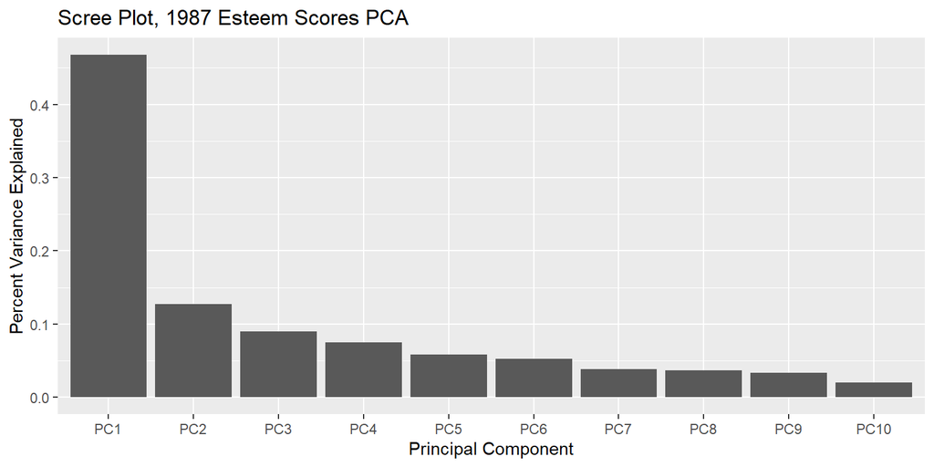

```r
# Convert proportion variance explained into data frame so we can use ggplot2.
esteem_PCA_PVE <- as.data.frame(summary(esteem_PCA)$importance[2,])

# Rename variables, create PC number variable and convert to factor.
esteem_PCA_PVE$PCA_Name <- rownames(esteem_PCA_PVE)
esteem_PCA_PVE$PCA_Name <- factor(esteem_PCA_PVE$PCA_Name, levels = c("PC1","PC2","PC3","PC4","PC5","PC6","PC7","PC8","PC9","PC10"))

# Plot scree plot
esteem_PCA_PVE %>%
  ggplot(aes(x = PCA_Name, y = summary(esteem_PCA)$importance[2, ])) +
  geom_bar(stat = "identity") +
  ggtitle("Scree Plot, 1987 Esteem Scores PCA")+
  xlab("Principal Component") +
  ylab("Percent Variance Explained")
```

6. Also plot CPVE (Cumulative Proportion of Variance Explained). What proportion of the variance in the data is explained by the first two principal components?

**Response:** Below is the plot of CPVE for the 10 principal components. The proportion of the variance in the esteem data explained by PC1 and PC2 is approximately 0.593.

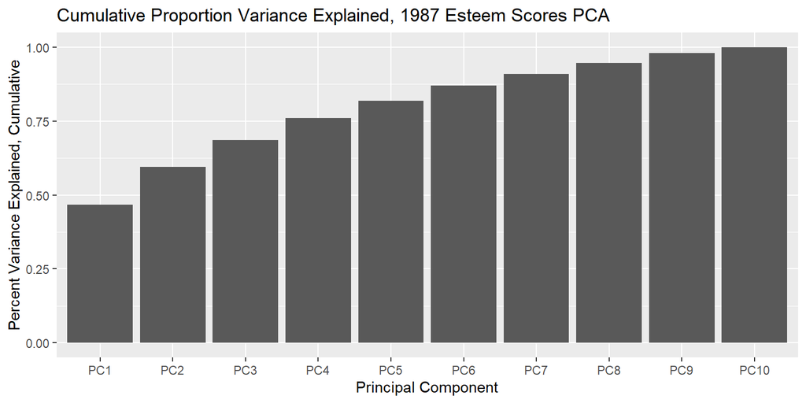

```r
# Convert proportion variance explained into data frame so we can use ggplot2.
esteem_PCA_CPVE <- as.data.frame(summary(esteem_PCA)$importance[3,])

# Rename variables, create PC number variable and convert to factor.
esteem_PCA_CPVE$PCA_Name <- rownames(esteem_PCA_CPVE)
esteem_PCA_CPVE$PCA_Name <- factor(esteem_PCA_CPVE$PCA_Name, levels = c("PC1","PC2","PC3","PC4","PC5","PC6","PC7","PC8","PC9","PC10"))

# Plot scree plot.
esteem_PCA_CPVE %>%
  ggplot(aes(x = PCA_Name, y = summary(esteem_PCA)$importance[3, ])) +
  geom_bar(stat = "identity") +
  ggtitle("Cumulative Proportion Variance Explained, 1987 Esteem Scores PCA")+
  xlab("Principal Component") +
  ylab("Percent Variance Explained, Cumulative")
```

7. PC’s provide us with a low dimensional view of the self-esteem scores. Use a biplot with the first two PC’s to display the data. Give an interpretation of PC1 and PC2 from the plot. (try `ggbiplot` if you could, much prettier!)

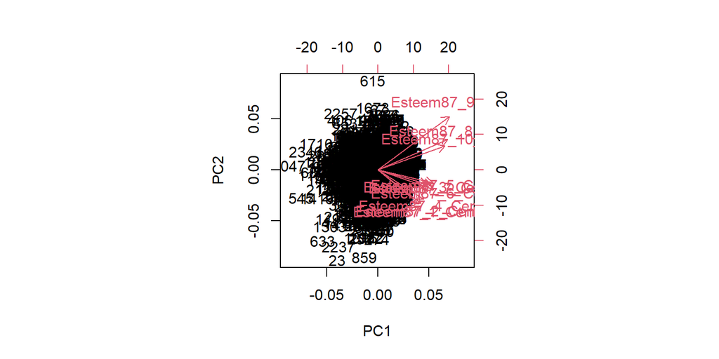

```r
# Generate biplot of PC1 and PC2.
esteem_PCA_biplot <- biplot(esteem_PCA)
```

5. Apply k-means to cluster subjects on the original esteem scores.
1. Find a reasonable number of clusters using within sum of squared with elbow rules.

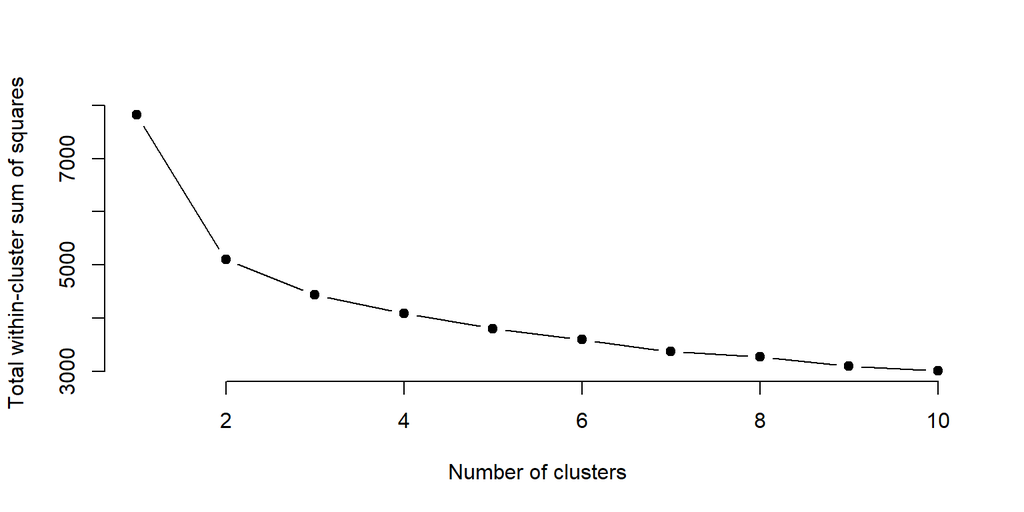

```r
set.seed(0)

# Create function to compute total within-cluster sum of squares.
wss <- function(df, k) {
  kmeans(df, k, nstart = 10)$tot.withinss
}

# Compute and plot within-cluster sum of squares for k = 1 to k = 10
k.values <- 1:10

# Extract within-cluster sum of squares for 1-10 clusters and plot.
wss_values <- map_dbl(k.values, function(k) wss(Esteem_Data_1987[,-1], k))

plot(k.values, wss_values,
       type="b", pch = 19, frame = FALSE,
       xlab="Number of clusters",
       ylab="Total within-cluster sum of squares")
```

2. Can you summarize common features within each cluster?

```r
set.seed(1)

# Perform k-means clustering on 1987 esteem data.
esteem_Kmeans <- Esteem_Data_1987 %>%
  kmeans(centers = 3)

# Merge cluster data into 1987 esteem data.
Esteem_Data_1987_grouped <- Esteem_Data_1987 %>%
  mutate(group = esteem_Kmeans$cluster)

# Report table of 1987 esteem data by cluster.
Esteem_Data_1987_grouped_flat <- Esteem_Data_1987_grouped %>%
  group_by(group) %>%
  summarise_each(funs(mean))

tibble(Esteem_Data_1987_grouped_flat)
```

```
## # A tibble: 3 x 11
##   group Esteem87_1 Esteem87_2 Esteem87_3 Esteem87_4 Esteem87_5 Esteem87_6
##   <int>      <dbl>      <dbl>      <dbl>      <dbl>      <dbl>      <dbl>
## 1     1       3.10       3.06       3.13       3.05       3.04       2.97
## 2     2       3.90       3.86       3.68       3.63       3.60       3.43
## 3     3       3.88       3.88       3.94       3.82       3.96       3.82
## # ... with 4 more variables: Esteem87_7 <dbl>, Esteem87_8 <dbl>,
## #   Esteem87_9 <dbl>, Esteem87_10 <dbl>
```

3. Can you visualize the clusters with somewhat clear boundaries? You may try different pairs of variables and different PC pairs of the esteem scores.

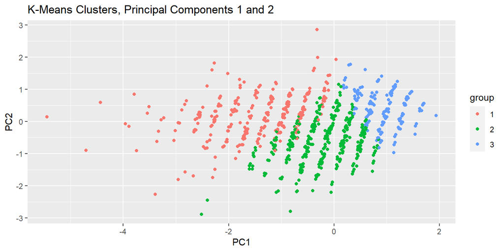

```r
# Merge groups to centered 1987 esteem data set.
Esteem_Data_1987_centered_wPCAandGroups <- Esteem_Data_1987_centered %>%
  mutate(group = factor(esteem_Kmeans$cluster))

# Merge PC scores (first 5) to centered 1987 esteem data set.
Esteem_Data_1987_centered_wPCAandGroups <- Esteem_Data_1987_centered_wPCAandGroups %>%
  mutate(PC1 = esteem_PCA$x[,1]) %>%
  mutate(PC2 = esteem_PCA$x[,2]) %>%
  mutate(PC3 = esteem_PCA$x[,3]) %>%
  mutate(PC4 = esteem_PCA$x[,4]) %>%
  mutate(PC5 = esteem_PCA$x[,5])

# Plot PC1 and PC2 by group.
Esteem_Data_1987_centered_wPCAandGroups %>%
  ggplot(aes(x = PC1,y = PC2, col = group))+
  geom_point() +
  ggtitle("K-Means Clusters, Principal Components 1 and 2")
```

6. We now try to find out what factors are related to self-esteem? PC1 of all the Esteem scores is a good variable to summarize one’s esteem scores. We take PC1 as our response variable.
1. Prepare possible factors:

**Note:** We interpreted “prepare factors” as asking us to perform factor analysis over the non-esteem measures; therefore, we performed PCA in order to reduce the dimensionality of the additional factors while still capturing sufficient information about each subject.

- Personal information: gender, education, log(income), job type, Body mass index as a measure of health (The BMI is defined as the body mass divided by the square of the body height, and is universally expressed in units of kg/m²)

**Response:** Below we derive principal components for respondents’ personal information: `Gender` and `log_Income87`. Per review of the scree plot, the first two principal components pass the elbow rule.

```r
# Create several new variables.
Question_1_clean_final <- Question_1_clean %>%
  mutate(Gender_numeric = as.integer(factor(Gender))) %>%
  mutate(log_Income87 = log(Income87+1)) %>% #add 1 to avoid getting infinity
  mutate(log_Income05 = log(Income05+1)) %>% #add 1 to avoid getting infinity
  mutate(Job05_numeric = as.integer(factor(Job05))) %>% #convert to integer to center and scale. This avoids this variable having too much weight in the PCs because it is on a different scale.
  mutate(Weight05_kg = Weight05*0.453592) %>%
  mutate(Height05_meter = (HeightFeet05 + HeightInch05*(1/12))*0.3048) %>%
  mutate(BMI05 = Weight05_kg*(Height05_meter^-2))

# Perform PCA on personal information.
Personal_Info_Data <- Question_1_clean_final %>%
  select(Gender_numeric,log_Income87)

Personal_Info_PCA <- prcomp(Personal_Info_Data,center = TRUE,scale. = TRUE)

Personal_Info_PCA$rotation[,c(1,2)]
```

```
##                  PC1    PC2
## Gender_numeric 0.707  0.707
## log_Income87   0.707 -0.707
```

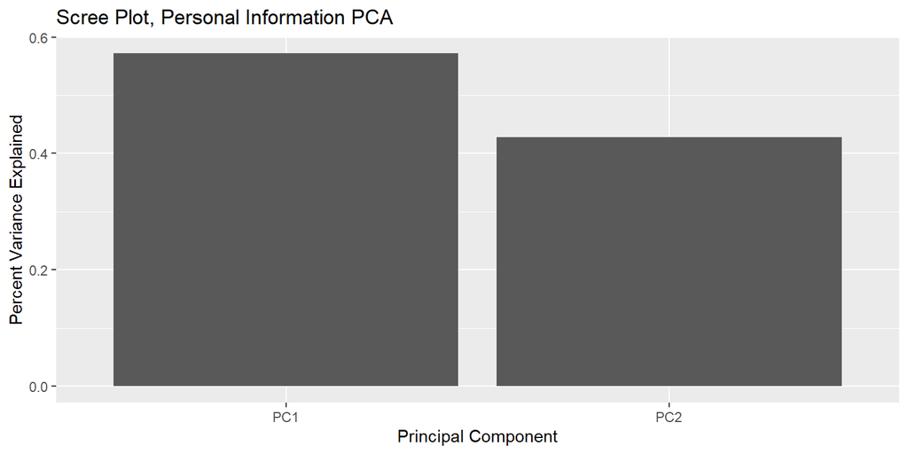

```r
# Convert proportion variance explained into data frame so we can use ggplot2.
Personal_Info_PCA_PVE <- as.data.frame(summary(Personal_Info_PCA)$importance[2,])

# Rename variables, create PC number variable and convert to factor.
Personal_Info_PCA_PVE$PCA_Name <- rownames(Personal_Info_PCA_PVE)
Personal_Info_PCA_PVE$PCA_Name <- factor(Personal_Info_PCA_PVE$PCA_Name, levels = c("PC1","PC2"))

# Plot scree plot
Personal_Info_PCA_PVE %>%
  ggplot(aes(x = PCA_Name, y = summary(Personal_Info_PCA)$importance[2, ])) +
  geom_bar(stat = "identity") +
  ggtitle("Scree Plot, Personal Information PCA")+
  xlab("Principal Component") +
  ylab("Percent Variance Explained")
```

- Household environment: Imagazine, Inewspaper, Ilibrary, MotherEd, FatherEd, FamilyIncome78. Do set indicators `Imagazine` and `Ilibrary` as factors.

**Response:** Below we derive principal components for respondents’ household environment: `Imagazine`, `Inewspaper`, `Ilibrary`, `log_FamilyIncome78`. Per review of the scree plot, the first principal component passes the elbow rule.

```r
# Create several new variables.
Question_1_clean_final <- Question_1_clean_final %>%
  mutate(Imagazine = as.integer(factor(Imagazine))) %>%  #convert to integer to center and scale. This avoids this variable having too little weight in the PCs because it is on a different scale.
  mutate(Inewspaper = as.integer(factor(Inewspaper))) %>%  #convert to integer to center and scale. This avoids this variable having too little weight in the PCs because it is on a different scale.
  mutate(Ilibrary = as.integer(factor(Ilibrary))) %>%  #convert to integer to center and scale. This avoids this variable having too little weight in the PCs because it is on a different scale.)
  mutate(log_FamilyIncome78 = log(FamilyIncome78+1)) #add 1 to avoid having infinite values.

# Perform PCA on household environment.
Household_Data <- Question_1_clean_final %>%
  select(Imagazine,Inewspaper,Ilibrary,log_FamilyIncome78)

Household_PCA <- prcomp(Household_Data,center = TRUE,scale. = TRUE)

Household_PCA$rotation[,c(1,2)]
```

```
##                       PC1     PC2
## Imagazine          -0.517 -0.1504
## Inewspaper         -0.559  0.0648
## Ilibrary           -0.449  0.7547
## log_FamilyIncome78 -0.468 -0.6353
```

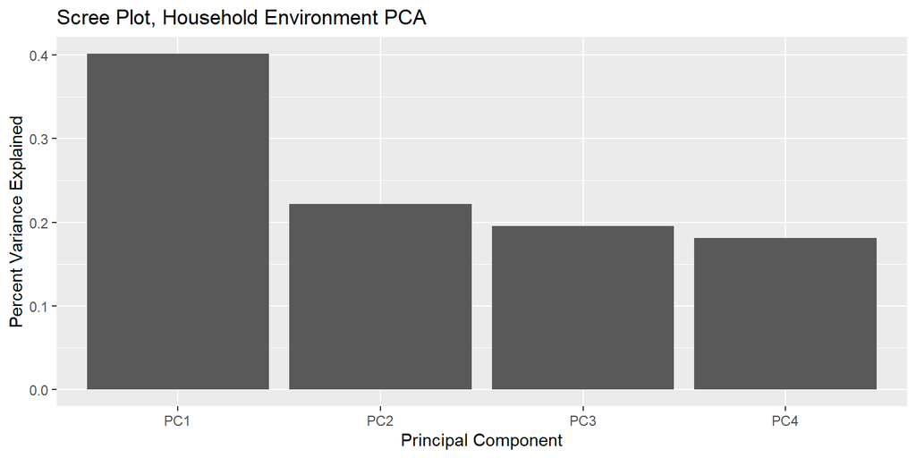

```r
# Convert proportion variance explained into data frame so we can use ggplot2.
Household_PCA_PVE <- as.data.frame(summary(Household_PCA)$importance[2,])

# Rename variables, create PC number variable and convert to factor.
Household_PCA_PVE$PCA_Name <- rownames(Household_PCA_PVE)
Household_PCA_PVE$PCA_Name <- factor(Household_PCA_PVE$PCA_Name, levels = c("PC1","PC2","PC3","PC4"))

# Plot scree plot
Household_PCA_PVE %>%
  ggplot(aes(x = PCA_Name, y = summary(Household_PCA)$importance[2, ])) +
  geom_bar(stat = "identity") +
  ggtitle("Scree Plot, Household Environment PCA")+
  xlab("Principal Component") +
  ylab("Percent Variance Explained")
```

- Use PC1 of SVABS as level of intelligence

```r
# Perform PCA on SVABS.
SVABS_Data <- Question_1_clean_final %>%
  select(Science,Arith,Word,Parag,Number,Coding,Auto,Math,Mechanic,Elec)

SVABS_PCA <- prcomp(SVABS_Data,center = TRUE,scale. = TRUE)

SVABS_PCA$rotation[,c(1,2)]
```

```
##            PC1     PC2
## Science  0.353 -0.1421
## Arith    0.356  0.0478
## Word     0.350  0.0611
## Parag    0.325  0.1867
## Number   0.272  0.4579
## Coding   0.231  0.5219
## Auto     0.274 -0.4621
## Math     0.338  0.1388
## Mechanic 0.316 -0.3345
## Elec     0.324 -0.3350
```

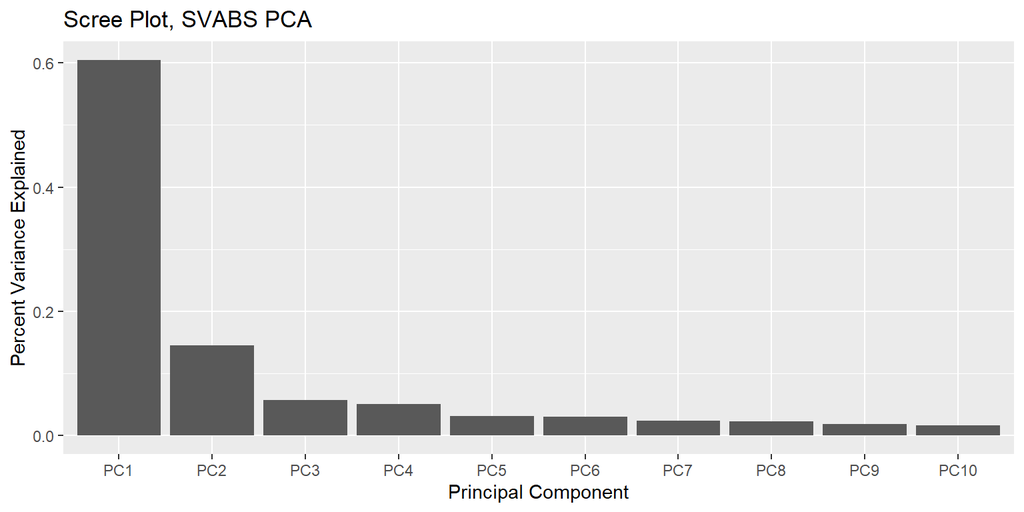

```r
# Convert proportion variance explained into data frame so we can use ggplot2.
SVABS_PCA_PVE <- as.data.frame(summary(SVABS_PCA)$importance[2,])

# Rename variables, create PC number variable and convert to factor.
SVABS_PCA_PVE$PCA_Name <- rownames(SVABS_PCA_PVE)
SVABS_PCA_PVE$PCA_Name <- factor(SVABS_PCA_PVE$PCA_Name, levels = c("PC1","PC2","PC3","PC4","PC5","PC6","PC7","PC8","PC9","PC10"))

# Plot scree plot
SVABS_PCA_PVE %>%
  ggplot(aes(x = PCA_Name, y = summary(SVABS_PCA)$importance[2, ])) +
  geom_bar(stat = "identity") +
  ggtitle("Scree Plot, SVABS PCA")+
  xlab("Principal Component") +
  ylab("Percent Variance Explained")
```

2. Run a few regression models between PC1 of all the esteem scores and factors listed in a). Find a final best model with your own criterion.

**Response:** We run linear regression models of `Esteem_PC1` on the four main principal components we derived and elected to keep above: `Personal_Info_PC1`, `Personal_Info_PC2`, `Household_PC1`, `SVABS_PC1`. The regression results are below; we believe that the final full model is the most appropriate as it includes as much information as possible while achieving the highest $R^2$, unadjusted and adjusted.

```r
# Merge in PC's calculated previously.
Question_1_clean_final <- Question_1_clean_final %>%
  mutate(Esteem_PC1 = esteem_PCA$x[,1]) %>%
  mutate(Esteem_PC2 = esteem_PCA$x[,2]) %>%
  mutate(Personal_Info_PC1 = Personal_Info_PCA$x[,1]) %>%
  mutate(Personal_Info_PC2 = Personal_Info_PCA$x[,2]) %>%
  mutate(Household_PC1 = Household_PCA$x[,1]) %>%
  mutate(SVABS_PC1 = SVABS_PCA$x[,1])

# Run piecewise and full regressions of Esteem PC1 on PCs calculated above.
Question_1_model1 <- lm(Esteem_PC1 ~ Personal_Info_PC1, data = Question_1_clean_final)
Question_1_model2 <- lm(Esteem_PC1 ~ Personal_Info_PC2, data = Question_1_clean_final)
Question_1_model3 <- lm(Esteem_PC1 ~ Household_PC1, data = Question_1_clean_final)
Question_1_model4 <- lm(Esteem_PC1 ~ SVABS_PC1, data = Question_1_clean_final)
Question_1_model5 <- lm(Esteem_PC1 ~ Personal_Info_PC1+Personal_Info_PC2+Household_PC1+SVABS_PC1, data = Question_1_clean_final)

# Output clean regression tables.
stargazer(Question_1_model1,Question_1_model2,Question_1_model3,Question_1_model4,Question_1_model5,title = "Regression Results", align=TRUE,type = "html",header = FALSE)
```

**Regression Results**

|  | *Dependent variable:* |  |  |  |  |
| --- | --- | --- | --- | --- | --- |
|  | Esteem_PC1 |  |  |  |  |
|  | (1) | (2) | (3) | (4) | (5) |
| Personal_Info_PC1 | 0.142*** |  |  |  | 0.070*** |
|  | (0.025) |  |  |  | (0.025) |
| Personal_Info_PC2 |  | -0.065** |  |  | -0.051* |
|  |  | (0.029) |  |  | (0.028) |
| Household_PC1 |  |  | -0.186*** |  | -0.082*** |
|  |  |  | (0.021) |  | (0.022) |
| SVABS_PC1 |  |  |  | 0.144*** | 0.118*** |
|  |  |  |  | (0.010) | (0.012) |
| Constant | -0.000 | -0.000 | 0.000 | 0.000 | 0.000 |
|  | (0.027) | (0.027) | (0.026) | (0.026) | (0.026) |
| Observations | 2,346 | 2,346 | 2,346 | 2,346 | 2,346 |
| R<sup>2</sup> | 0.014 | 0.002 | 0.033 | 0.074 | 0.085 |
| Adjusted R<sup>2</sup> | 0.013 | 0.002 | 0.033 | 0.074 | 0.083 |
| Residual Std. Error | 1.290 (df = 2344) | 1.290 (df = 2344) | 1.270 (df = 2344) | 1.250 (df = 2344) | 1.240 (df = 2341) |
| F Statistic | 32.800*** (df = 1; 2344) | 5.030** (df = 1; 2344) | 80.200*** (df = 1; 2344) | 189.000*** (df = 1; 2344) | 54.000*** (df = 4; 2341) |
| *Note:* | p<0.1; p<0.05; p<0.01 |  |  |  |  |

- How did you land this model? Run a model diagnosis to see if the linear model assumptions are reasonably met.

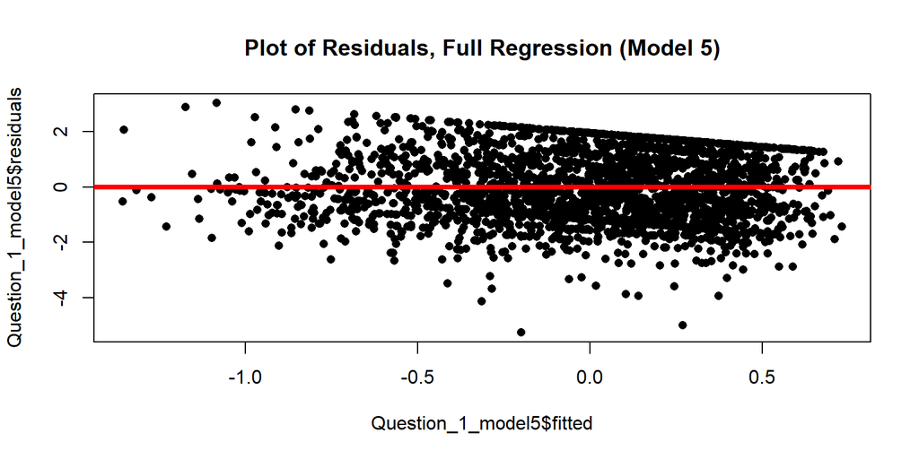

```r
# Generate residual plot.
plot(Question_1_model5$fitted, Question_1_model5$residuals,
     pch  = 16,
     main = "Plot of Residuals, Full Regression (Model 5)")
abline(h=0, lwd=4, col="red")
```

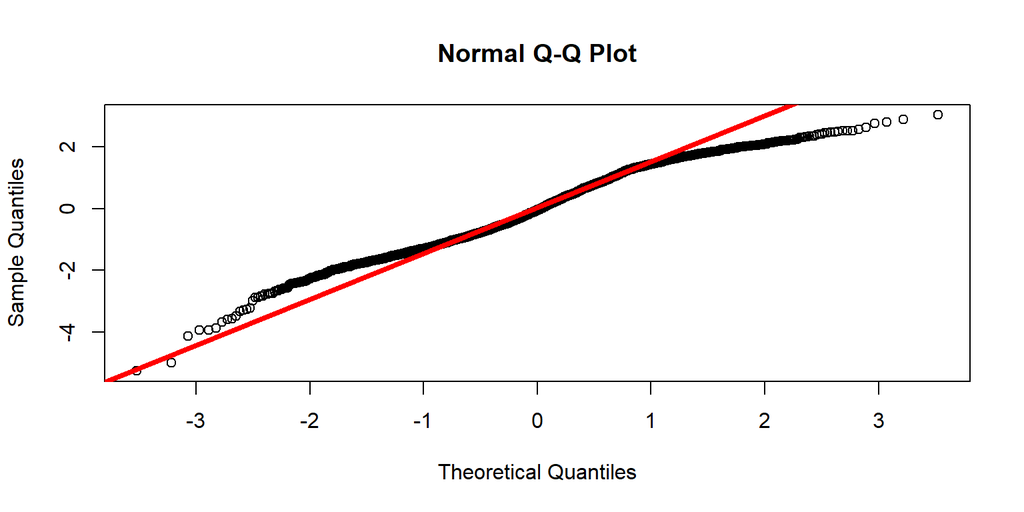

```r
# Generate QQ plots.
qqnorm(Question_1_model5$residuals)
qqline(Question_1_model5$residuals, lwd=4, col="red")
```

- Write a summary of your findings. In particular, explain what and how the variables in the model affect one’s self-esteem.

**Response:** We review the results of the model variable-by-variable:

# 2 Case study 2: Breast cancer sub-type

[The Cancer Genome Atlas (TCGA)](https://www.cancer.gov/about-nci/organization/ccg/research/structural-genomics/tcga), a landmark cancer genomics program by National Cancer Institute (NCI), molecularly characterized over 20,000 primary cancer and matched normal samples spanning 33 cancer types. The genome data is open to public from the [Genomic Data Commons Data Portal (GDC)](https://portal.gdc.cancer.gov/).

In this study, we focus on 4 sub-types of breast cancer (BRCA): basal-like (basal), Luminal A-like (lumA), Luminal B-like (lumB), HER2-enriched. The sub-type is based on PAM50, a clinical-grade luminal-basal classifier.

- Luminal A cancers are low-grade, tend to grow slowly and have the best prognosis.
- Luminal B cancers generally grow slightly faster than luminal A cancers and their prognosis is slightly worse.
- HER2-enriched cancers tend to grow faster than luminal cancers and can have a worse prognosis, but they are often successfully treated with targeted therapies aimed at the HER2 protein.
- Basal-like breast cancers or triple negative breast cancers do not have the three receptors that the other sub-types have so have fewer treatment options.

We will try to use mRNA expression data alone without the labels to classify 4 sub-types. Classification without labels or prediction without outcomes is called unsupervised learning. We will use K-means and spectrum clustering to cluster the mRNA data and see whether the sub-type can be separated through mRNA data.

We first read the data using `data.table::fread()` which is a faster way to read in big data than `read.csv()`.

```r
brca <- fread("data/brca_subtype.csv")
rownames(brca) <-  paste("p", seq(1:nrow(brca)), sep="")

# Get the sub-type information.
brca_subtypes <- data.frame(brca$BRCA_Subtype_PAM50)
brca <- brca[,-1]
```

1. Summary and transformation
1. How many patients we have in each sub-type?

**Response:** Below is the histogram of observations by subtype. LumA is the most common at 628 observations, followed by LumB and Basal at approximately 233 and 208, respectively, with Her2 at 91.

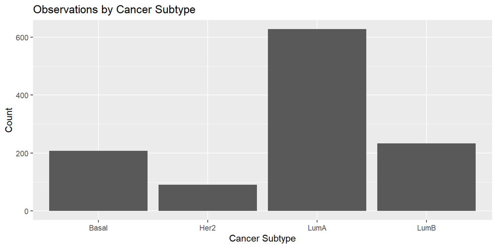

```r
# Generate bar chart.
brca_subtypes %>%
  ggplot(aes(x = brca.BRCA_Subtype_PAM50))+
  geom_bar() +
  ggtitle("Observations by Cancer Subtype")+
  xlab("Cancer Subtype")+
  ylab("Count")
```

2. Randomly pick 5 genes and plot the histogram by each sub-type.

**Response:** Below are histograms by subtype of 5 randomly selected genes. Note there is some observable variability between the subtypes.

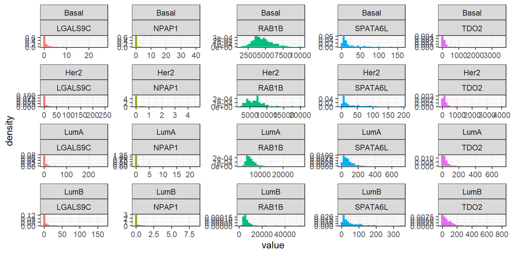

```r
# Get random sample of column numbers to pull.
set.seed(0)
sample_indices <- sort(sample(1:ncol(brca),5))

# Subset data and merge in subtype.
brca_sample <- brca[,..sample_indices]
brca_sample$subtype <- brca_subtypes$brca.BRCA_Subtype_PAM50

# Plot histograms by subtype.
brca_sample %>%
  pivot_longer(!subtype) %>%     # for facet(0)
  ggplot(aes(x = value, y = ..density..)) +
  geom_histogram(aes(fill = name)) +
  facet_wrap(subtype ~ name, scales = "free") +
  theme_bw() +
  theme(legend.position = "none")
```

3. Remove gene with zero count and no variability. Then apply logarithmic transform.

**Response:** Below we make the required corrections, removing genes with all zero values and genes whose column variance is equal to zero. We finally apply a base 2 log transformation.

```r
# Remove genes with 0 counts.
sel_cols1 <- which(colSums(abs(brca)) != 0)
brca_sub <- brca[, sel_cols1, with=F]

# Remove genes with variance = 0.
sel_cols2 <- which(apply(brca_sub, 2, var) != 0)
brca_sub <- brca_sub[, sel_cols2, with=F]

# Apply base-2 log transformation.
brca_sub <- log2(as.data.frame(brca_sub+1e-10))
```

2. Apply kmeans on the transformed dataset with 4 centers and output the discrepancy table between the real sub-type `brca_subtype` and the cluster labels.

**Response:** Below we report the discrepancy table between the actual subtype and the cluster assignment for each observation. The clustering performs reasonably well; in particular, it is able to easily differentiate between the basal subtype (cluster 4 below) and the others.

```r
set.seed(1)

# Perform kmeans with 4 centers.
brca_sub_kmeans <- kmeans(x = brca_sub, 4)

# Output table of cluster assignments by subtype.
table(brca_subtypes$brca.BRCA_Subtype_PAM50, brca_sub_kmeans$cluster)
```

```
##
##           1   2   3   4
##   Basal   3  17   1 187
##   Her2   23   9  43  16
##   LumA  147  86 395   0
##   LumB  105  22 104   2
```

3. Spectrum clustering: to scale or not to scale?
1. Apply PCA on the centered and scaled dataset. How many PCs should we use and why? You are encouraged to use `irlba::irlba()`.

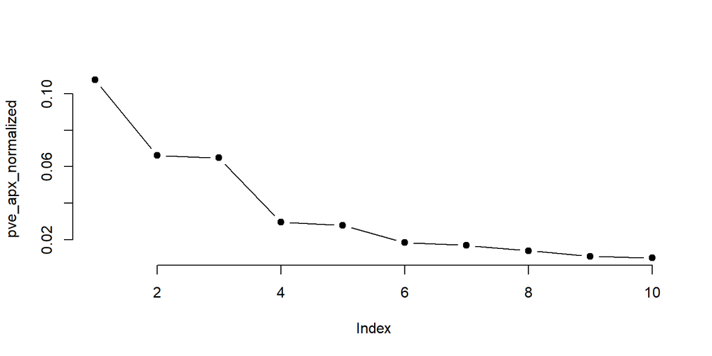

```r
# Normalize brca_sub
brca_sub_normalized <- as.matrix(scale(brca_sub))

# Use irlba to perform SVD and obtain leading PCs.
pca_brca_normalized <- irlba::irlba(brca_sub_normalized, nv = 10)

# Approximate the PVE.
pca_var_brca_normalized <- pca_brca_normalized$d^2/(nrow(brca_sub_normalized)-1)
pve_apx_normalized <- pca_var_brca_normalized/(ncol(brca_sub_normalized))
plot(pve_apx_normalized, type="b", pch = 19, frame = FALSE)
```

2. Plot PC1 vs PC2 of the centered and scaled data and PC1 vs PC2 of the centered but unscaled data side by side. Should we scale or not scale for clustering purposes? Why? (Hint: to put plots side by side, use `gridExtra::grid.arrange()` or `ggpubr::ggarrange()` or `egg::ggrrange()` for ggplots; use `fig.show="hold"` as chunk option for base plots)

**Response:** Below we report the cluster assignments by PC1 and PC2 for the four clusters. It appears that the centered PCs better separate the clusters. This may be due to the fact that scaling the variables inherently obscures their relative variances - centering but not scaling gives more weight to high-variance variables, whereas centering and scaling does not have this effect.

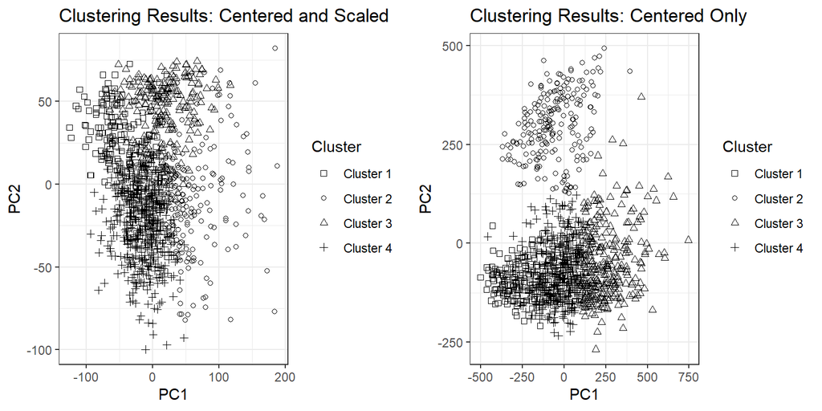

```r
set.seed(0)

# Center brca_sub
brca_sub_centered <- as.matrix(scale(brca_sub,center = TRUE,scale = FALSE))

# Use irlba to perform SVD and obtain leading PCs.
pca_brca_centered <- irlba::irlba(brca_sub_centered, nv = 10)

# Save normalized PC scores
pc_score_brca_normalized <- as.data.frame(brca_sub_normalized %*% pca_brca_normalized$v[, 1:4])

# Save centered PC scores
pc_score_brca_centered <- as.data.frame(brca_sub_centered %*% pca_brca_centered$v[, 1:4])

# Plot PC1 vs PC2: Normalized
kmean_ret_normalized <- pc_score_brca_normalized %>%
  kmeans(centers = 4)

clusters_normalized <- data.table(x = pc_score_brca_normalized[,1],
                y = pc_score_brca_normalized[,2],
                col = as.factor(brca_subtypes$brca.BRCA_Subtype_PAM50),
                cl = as.factor(kmean_ret_normalized$cluster)) %>%
  ggplot() +
  geom_point(aes(x = x, y = y, shape = cl)) +
  #scale_color_manual(labels = c("LumA", "LumB", "Basal", "Her2"), values = scales::hue_pal()(4)) +
  scale_shape_manual(labels = c("Cluster 1", "Cluster 2", "Cluster 3", "Cluster 4"),
                     values = c(0, 1, 2, 3)) +
  theme_bw() +
  labs(shape = "Cluster") +
  xlab("PC1") +
  ylab("PC2") +
  ggtitle("Clustering Results: Centered and Scaled")

# Plot PC1 vs PC2: Centered
kmean_ret_centered <- pc_score_brca_centered %>%
  kmeans(centers = 4)

clusters_centered <- data.table(x = pc_score_brca_centered[,1],
                y = pc_score_brca_centered[,2],
                col = as.factor(brca_subtypes$brca.BRCA_Subtype_PAM50),
                cl = as.factor(kmean_ret_centered$cluster)) %>%
  ggplot() +
  geom_point(aes(x = x, y = y, shape = cl)) +
  #scale_color_manual(labels = c("LumA", "LumB", "Basal", "Her2"), values = scales::hue_pal()(4)) +
  scale_shape_manual(labels = c("Cluster 1", "Cluster 2", "Cluster 3", "Cluster 4"),
                     values = c(0, 1, 2, 3)) +
  theme_bw() +
  labs(shape = "Cluster") +
  xlab("PC1") +
  ylab("PC2") +
  ggtitle("Clustering Results: Centered Only")

ggpubr::ggarrange(clusters_normalized,clusters_centered)
```

4. Spectrum clustering: center but do not scale the data
1. Use the first 4 PCs of the centered and unscaled data and apply kmeans. Find a reasonable number of clusters using within sum of squared with the elbow rule.

**Response:** Using the within-cluster sum of squares scree plot below, 4 clusters seems appropriate as there is a defined kink after the 4th cluster.

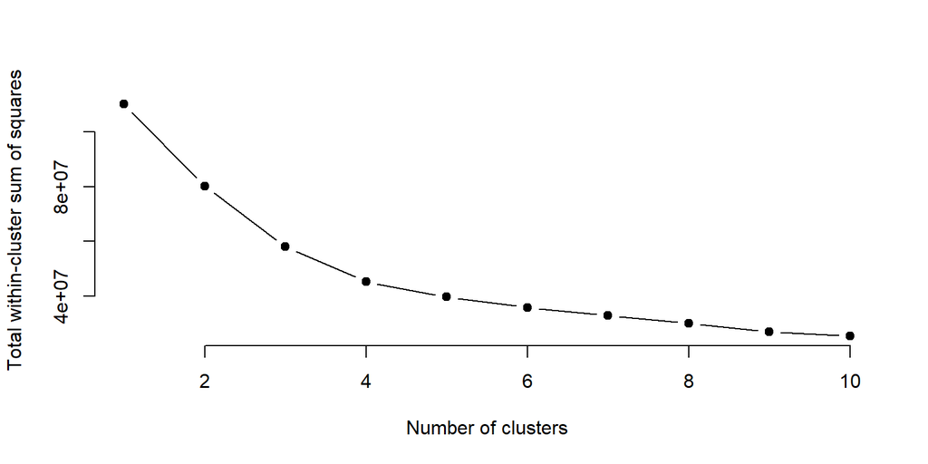

```r
set.seed(0)

# Create function to compute total within-cluster sum of squares.
wss <- function(df, k) {
  kmeans(df, k, nstart = 10)$tot.withinss
}

# Compute and plot within-cluster sum of squares for k = 1 to k = 10
k.values <- 1:10

# Extract within-cluster sum of squares for 1-10 clusters and plot.
wss_values <- map_dbl(k.values, function(k) wss(pc_score_brca_centered, k))

plot(k.values, wss_values,
       type="b", pch = 19, frame = FALSE,
       xlab="Number of clusters",
       ylab="Total within-cluster sum of squares")
```

2. Choose an optimal cluster number and apply kmeans. Compare the real sub-type and the clustering label as follows: Plot scatter plot of PC1 vs PC2. Use point color to indicate the true cancer type and point shape to indicate the clustering label. Plot the kmeans centroids with black dots. Summarize how good is clustering results compared to the real sub-type.

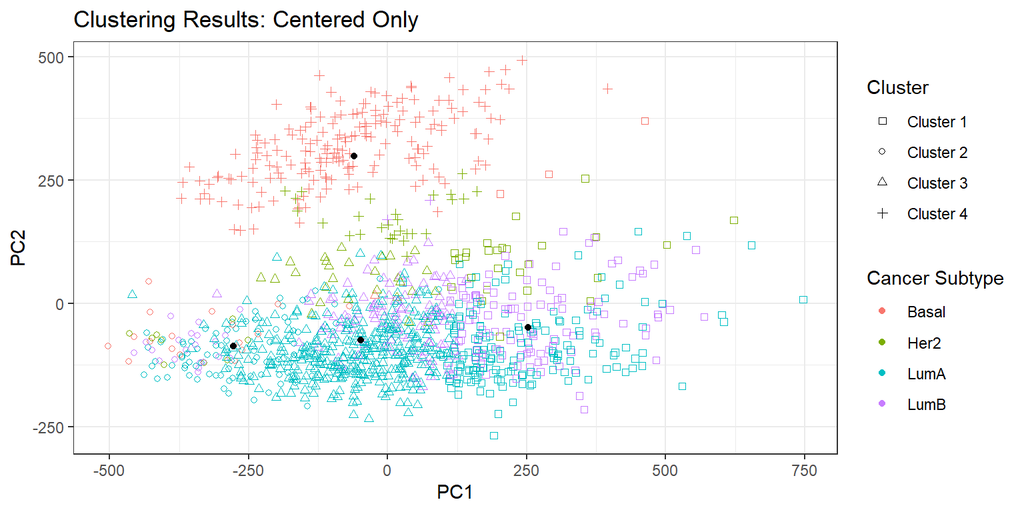

```r
set.seed(0)

# Plot PC1 vs PC2: Centered
kmean_ret_centered <- pc_score_brca_centered %>%
  kmeans(centers = 4)

kmean_ret_centered_centroids <- as.data.table(kmean_ret_centered$centers)

clusters_centered_v2 <- data.table(x = pc_score_brca_centered[,1],
                y = pc_score_brca_centered[,2],
                col = as.factor(brca_subtypes$brca.BRCA_Subtype_PAM50),
                cl = as.factor(kmean_ret_centered$cluster)) %>%
  ggplot() +
  geom_point(aes(x = x, y = y, color = col, shape = cl)) +
  scale_color_manual(labels = c("Basal", "Her2", "LumA", "LumB"), values = scales::hue_pal()(4)) +
  scale_shape_manual(labels = c("Cluster 1", "Cluster 2", "Cluster 3", "Cluster 4"),
                     values = c(0, 1, 2, 3)) +
  theme_bw() +
  labs(col = "Cancer Subtype", shape = "Cluster") +
  xlab("PC1") +
  ylab("PC2") +
  ggtitle("Clustering Results: Centered Only")+
  geom_point(aes(x = kmean_ret_centered_centroids$V1[1], y = kmean_ret_centered_centroids$V2[1]), colour="black")+
  geom_point(aes(x = kmean_ret_centered_centroids$V1[2], y = kmean_ret_centered_centroids$V2[2]), colour="black")+
  geom_point(aes(x = kmean_ret_centered_centroids$V1[3], y = kmean_ret_centered_centroids$V2[3]), colour="black")+
  geom_point(aes(x = kmean_ret_centered_centroids$V1[4], y = kmean_ret_centered_centroids$V2[4]), colour="black")

clusters_centered_v2
```

3. Compare the clustering result from applying kmeans to the original data and the clustering result from applying kmeans to 4 PCs. Does PCA help in kmeans clustering? What might be the reasons if PCA helps?

**Response:** Below are the accuracy results from clustering using the centered PCs:

```r
# Output table of cluster assignments by subtype.
table(brca_subtypes$brca.BRCA_Subtype_PAM50, kmean_ret_centered$cluster)
```

```
##
##           1   2   3   4
##   Basal   3  17   1 187
##   Her2   27   9  27  28
##   LumA  161  91 376   0
##   LumB  110  22  99   2
```

Below are the accuracy results from clustering the raw data:

```r
# Output table of cluster assignments by subtype.
table(brca_subtypes$brca.BRCA_Subtype_PAM50, brca_sub_kmeans$cluster)
```

```
##
##           1   2   3   4
##   Basal   3  17   1 187
##   Her2   23   9  43  16
##   LumA  147  86 395   0
##   LumB  105  22 104   2
```

4. Now we have an x patient with breast cancer but with unknown sub-type. We have this patient’s mRNA sequencing data. Project this x patient to the space of PC1 and PC2. (Hint: remember we remove some gene with no counts or no variablity, take log and centered) Plot this patient in the plot in iv) with a black dot. Calculate the Euclidean distance between this patient and each of centroid of the cluster. Can you tell which sub-type this patient might have?

**Response:** Projecting the given information for patient x onto the vector space of PC1 and PC2, we see that the patient appears to be a member of cluster 4 (refer to the large black dot on the below plot). Given that the patient is in the most accurate cluster as compared to all other clusters, which corresponds to Basal, it is likely that this patient has the Basal subtype.

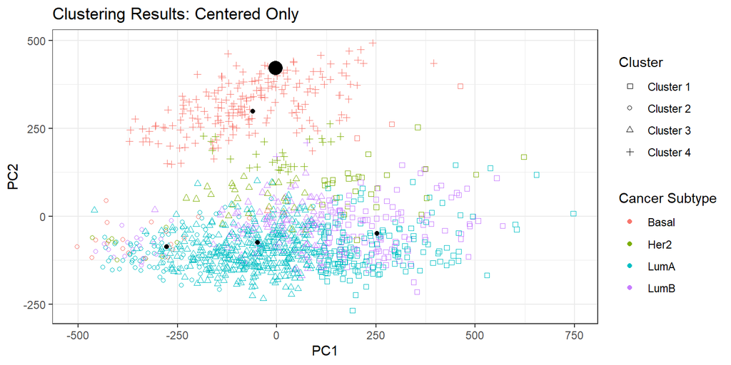

```r
x_patient <- fread("data/brca_x_patient.csv")

# Remove genes we removed before.
x_patient_sub <- x_patient[, sel_cols1, with=F]

# Apply base-2 log transformation.
x_patient_sub <- log2(as.data.frame(x_patient_sub+1e-10))

# Transform to "centered" measure by subtracting off the column mean of the full dataset.
x_patient_sub <- x_patient_sub - colMeans(brca_sub)

# Get PC scores for x patient.
pc_score_x_patient <- as.data.frame(as.matrix(x_patient_sub) %*% pca_brca_centered$v[, 1:4])

# Plot PC1 vs PC2: Centered
kmean_ret_centered <- pc_score_brca_centered %>%
  kmeans(centers = 4)

kmean_ret_centered_centroids <- as.data.table(kmean_ret_centered$centers)

clusters_centered_v3 <- clusters_centered_v2 +
  geom_point(aes(x = pc_score_x_patient$V1[1], y = pc_score_x_patient$V2[1]), colour="black", size = 5, shape = 19)

clusters_centered_v3
```

To calculate the Euclidean distance between patient x and the centroids of the four clusters, we perform the following analysis:

```r
print("Patient X to Centroid 1")
```

```
## [1] "Patient X to Centroid 1"
```

```r
dist(rbind(as.matrix(pc_score_x_patient),kmean_ret_centered_centroids[1,]),method = "euclidean",diag=FALSE)
```

```
##     1
## 2 501
```

```r
print("Patient X to Centroid 2")
```

```
## [1] "Patient X to Centroid 2"
```

```r
dist(rbind(as.matrix(pc_score_x_patient),kmean_ret_centered_centroids[2,]),method = "euclidean",diag=FALSE)
```

```
##     1
## 2 536
```

```r
print("Patient X to Centroid 3")
```

```
## [1] "Patient X to Centroid 3"
```

```r
dist(rbind(as.matrix(pc_score_x_patient),kmean_ret_centered_centroids[3,]),method = "euclidean",diag=FALSE)
```

```
##     1
## 2 623
```

```r
print("Patient X to Centroid 4")
```

```
## [1] "Patient X to Centroid 4"
```

```r
dist(rbind(as.matrix(pc_score_x_patient),kmean_ret_centered_centroids[4,]),method = "euclidean",diag=FALSE)
```

```
##     1
## 2 139
```

The Euclidean distances above corroborate patient x’s assignment to cluster 4; the patient’s PC scores have the lowest distance to its centroid.

# 3 Case study 3: Auto data set

This question utilizes the `Auto` dataset from ISLR. The original dataset contains 408 observations about cars. It is similar to the CARS dataset that we use in our lectures. To get the data, first install the package ISLR. The `Auto` dataset should be loaded automatically. We’ll use this dataset to practice the methods learn so far. Original data source is here: https://archive.ics.uci.edu/ml/datasets/auto+mpg

Get familiar with this dataset first. Tip: you can use the command `?ISLR::Auto` to view a description of the dataset.

## 3.1 EDA

Explore the data, with particular focus on pairwise plots and summary statistics. Briefly summarize your findings and any peculiarities in the data.

```r
Question_3_clean <- ISLR::Auto

# Skim the data.
skim(Question_3_clean)
```

Data summary

| Name | Question_3_clean |
| --- | --- |
| Number of rows | 392 |
| Number of columns | 9 |
| _______________________ |  |
| Column type frequency: |  |
| factor | 1 |
| numeric | 8 |
| ________________________ |  |
| Group variables | None |

**Variable type: factor**

| skim_variable | n_missing | complete_rate | ordered | n_unique | top_counts |
| --- | --- | --- | --- | --- | --- |
| name | 0 | 1 | FALSE | 301 | amc: 5, for: 5, toy: 5, amc: 4 |

**Variable type: numeric**

| skim_variable | n_missing | complete_rate | mean | sd | p0 | p25 | p50 | p75 | p100 | hist |
| --- | --- | --- | --- | --- | --- | --- | --- | --- | --- | --- |
| mpg | 0 | 1 | 23.45 | 7.81 | 9 | 17.0 | 22.8 | 29 | 46.6 | ▆▇▆▃▁ |
| cylinders | 0 | 1 | 5.47 | 1.71 | 3 | 4.0 | 4.0 | 8 | 8.0 | ▇▁▃▁▅ |
| displacement | 0 | 1 | 194.41 | 104.64 | 68 | 105.0 | 151.0 | 276 | 455.0 | ▇▂▂▃▁ |
| horsepower | 0 | 1 | 104.47 | 38.49 | 46 | 75.0 | 93.5 | 126 | 230.0 | ▆▇▃▁▁ |
| weight | 0 | 1 | 2977.58 | 849.40 | 1613 | 2225.2 | 2803.5 | 3615 | 5140.0 | ▇▇▅▅▂ |
| acceleration | 0 | 1 | 15.54 | 2.76 | 8 | 13.8 | 15.5 | 17 | 24.8 | ▁▆▇▂▁ |
| year | 0 | 1 | 75.98 | 3.68 | 70 | 73.0 | 76.0 | 79 | 82.0 | ▇▆▇▆▇ |
| origin | 0 | 1 | 1.58 | 0.81 | 1 | 1.0 | 1.0 | 2 | 3.0 | ▇▁▂▁▂ |

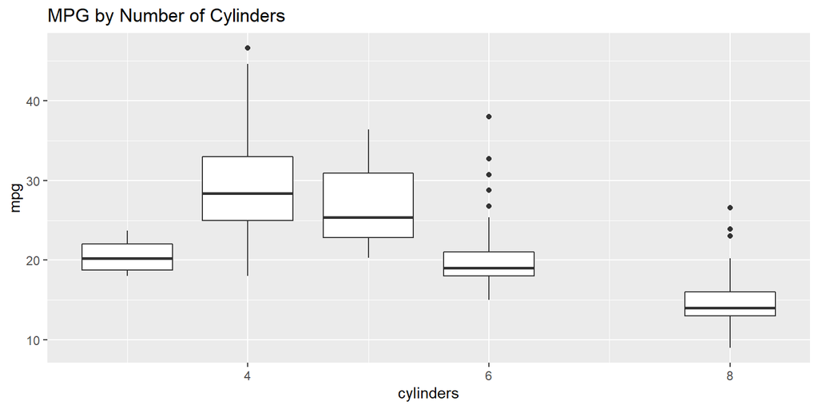

```r
# Present pairwise plots of mpg and variables of interest.
Question_3_clean %>%
  ggplot(aes(x = cylinders,y = mpg,group=cylinders))+
  geom_boxplot()+
  ggtitle("MPG by Number of Cylinders")
```

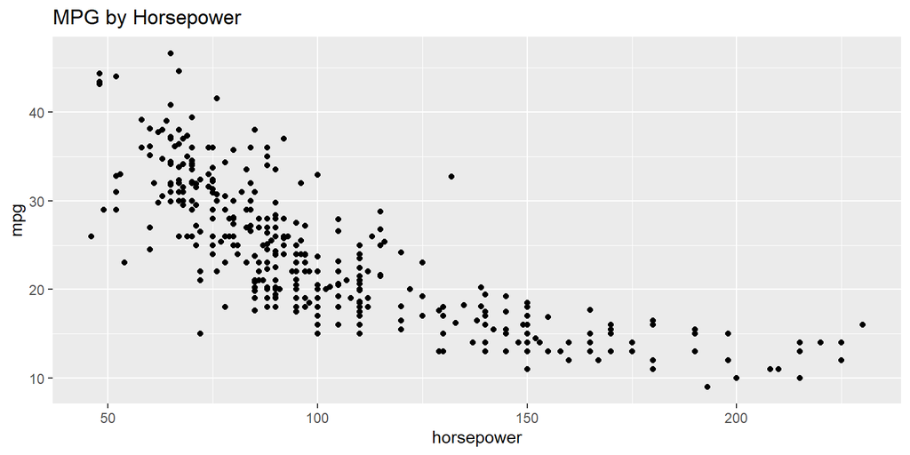

```r
Question_3_clean %>%
  ggplot(aes(x = horsepower,y = mpg))+
  geom_point()+
  ggtitle("MPG by Horsepower")
```

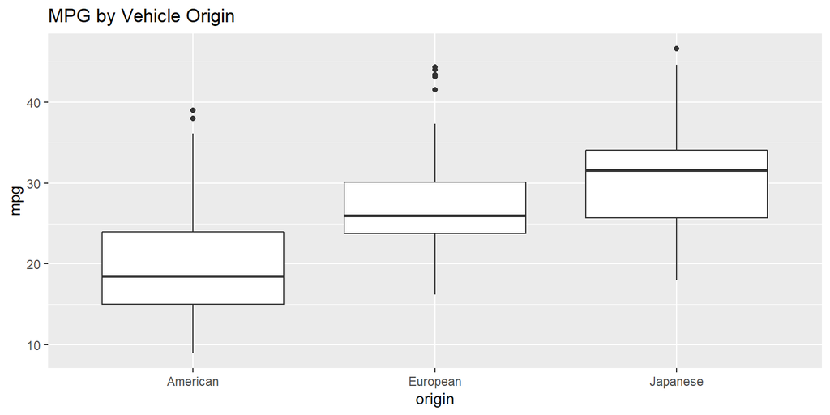

```r
Question_3_clean %>%
  ggplot(aes(x = as.factor(origin),y = mpg,group=as.factor(origin)))+
  geom_boxplot()+
  ggtitle("MPG by Vehicle Origin")+
  scale_x_discrete(labels=c("1" = "American", "2" = "European", "3" = "Japanese"))+
  xlab("origin")
```

## 3.2 What effect does `time` have on `MPG`?

1. Start with a simple regression of `mpg` vs. `year` and report R’s `summary` output. Is `year` a significant variable at the .05 level? State what effect `year` has on `mpg`, if any, according to this model.

**Response:** Per the results of the below linear regression, `year` is a significant variable at the .05 level. The results show that, for every increase in the year a car was produced, its miles per gallon increased 1.23 on average.

```r
Question_3_model1 <- lm(mpg ~ year, data = Question_3_clean)

summary(Question_3_model1)
```

```
##
## Call:
## lm(formula = mpg ~ year, data = Question_3_clean)
##
## Residuals:
##     Min      1Q  Median      3Q     Max
## -12.021  -5.441  -0.441   4.974  18.209
##
## Coefficients:
##             Estimate Std. Error t value Pr(>|t|)
## (Intercept) -70.0117     6.6452   -10.5   <2e-16 ***
## year          1.2300     0.0874    14.1   <2e-16 ***
## ---
## Signif. codes:  0 '***' 0.001 '**' 0.01 '*' 0.05 '.' 0.1 ' ' 1
##
## Residual standard error: 6.36 on 390 degrees of freedom
## Multiple R-squared:  0.337,  Adjusted R-squared:  0.335
## F-statistic:  198 on 1 and 390 DF,  p-value: <2e-16
```

2. Add `horsepower` on top of the variable `year` to your linear model. Is `year` still a significant variable at the .05 level? Give a precise interpretation of the `year`’s effect found here.

**Response:** While `year` remains a statistically significant correlate of `mpg`, its magnitude decreased somewhat. After controlling for `horsepower` and holding it fixed, we find that for every increase in the year a car was produced, its miles per gallon increased 0.66 on average.

```r
Question_3_model2 <- lm(mpg ~ year+horsepower, data = Question_3_clean)

summary(Question_3_model2)
```

```
##
## Call:
## lm(formula = mpg ~ year + horsepower, data = Question_3_clean)
##
## Residuals:
##     Min      1Q  Median      3Q     Max
## -12.077  -3.078  -0.431   2.588  15.315
##
## Coefficients:
##              Estimate Std. Error t value Pr(>|t|)
## (Intercept) -12.73917    5.34903   -2.38    0.018 *
## year          0.65727    0.06626    9.92   <2e-16 ***
## horsepower   -0.13165    0.00634  -20.76   <2e-16 ***
## ---
## Signif. codes:  0 '***' 0.001 '**' 0.01 '*' 0.05 '.' 0.1 ' ' 1
##
## Residual standard error: 4.39 on 389 degrees of freedom
## Multiple R-squared:  0.685,  Adjusted R-squared:  0.684
## F-statistic:  424 on 2 and 389 DF,  p-value: <2e-16
```

3. The two 95% CI’s for the coefficient of year differ among (i) and (ii). How would you explain the difference to a non-statistician?

**Response:** The confidence interval for the coefficient on year is [1.06, 1.4] for model 1 (which includes year only) compared to [0.527, 0.787] for model 2 (which includes both year and horsepower). Notice that the two confidence intervals are different, and model 2’s confidence interval is narrower. Let’s focus on model 2. We are 95% certain that the true effect of year on mpg is between 0.527 and 0.787 mpg. That is we are 95% confident that increasing the year by 1, increases mpg by between 0.527 and 0.787 mpg on average (holding horsepower constant). The reason that the confidence interval is narrower in model 2 is due to the fact that model 2 is more precise (because we have included additional variables i.e. horsepower to help better explain the covariates’ effects on mpg).

```r
#Note: If we have large number of observations n, the 95% confidence t-interval for each beta coefficient is beta +/- 1.96*se(beta)

#Regression with year only:
1.23 - 1.96*(.0874) #Lower limit of confidence interval = 1.06
```

```
## [1] 1.06
```

```r
1.23 + 1.96*(.0874) #Upper limit of confidence interval = 1.4
```

```
## [1] 1.4
```

```r
1.4 - 1.06 #Width of confidence interval = 0.34
```

```
## [1] 0.34
```

```r
#Regression with year and horsepower:
0.65727 - 1.96*(.06626) #Lower limit of confidence interval = 0.527
```

```
## [1] 0.527
```

```r
0.65727 + 1.96*(.06626) #Upper limit of confidence interval = 0.787
```

```
## [1] 0.787
```

```r
0.787 - 0.527 #Width of confidence interval = 0.26
```

```
## [1] 0.26
```

4. Create a model with interaction by fitting `lm(mpg ~ year * horsepower)`. Is the interaction effect significant at .05 level? Explain the year effect (if any).

```r
Question_3_model3 <- lm(mpg ~ year+horsepower+year*horsepower, data = Question_3_clean)

summary(Question_3_model3)
```

```
##
## Call:
## lm(formula = mpg ~ year + horsepower + year * horsepower, data = Question_3_clean)
##
## Residuals:
##     Min      1Q  Median      3Q     Max
## -12.349  -2.451  -0.456   2.406  14.444
##
## Coefficients:
##                  Estimate Std. Error t value Pr(>|t|)
## (Intercept)     -1.27e+02   1.21e+01  -10.45   <2e-16 ***
## year             2.19e+00   1.61e-01   13.59   <2e-16 ***
## horsepower       1.05e+00   1.15e-01    9.06   <2e-16 ***
## year:horsepower -1.60e-02   1.56e-03  -10.22   <2e-16 ***
## ---
## Signif. codes:  0 '***' 0.001 '**' 0.01 '*' 0.05 '.' 0.1 ' ' 1
##
## Residual standard error: 3.9 on 388 degrees of freedom
## Multiple R-squared:  0.752,  Adjusted R-squared:  0.75
## F-statistic:  393 on 3 and 388 DF,  p-value: <2e-16
```

## 3.3 Categorical predictors

Remember that the same variable can play different roles! Take a quick look at the variable `cylinders`, and try to use this variable in the following analyses wisely. We all agree that a larger number of cylinders will lower mpg. However, we can interpret `cylinders` as either a continuous (numeric) variable or a categorical variable.

1. Fit a model that treats `cylinders` as a continuous/numeric variable. Is `cylinders` significant at the 0.01 level? What effect does `cylinders` play in this model?

**Response:** Reviewing the results from the regression of `mpg` on `cylinders` as a continuous variable, the number of cylinders is statistically significantly related (p < .01) to a car’s mileage per gallon. Specifically, increasing a car’s number of cylinders by 1 will decrease `mpg` by 3.558.

```r
Question_3_model4 <- lm(mpg ~ cylinders, data = Question_3_clean)

summary(Question_3_model4)
```

```
##
## Call:
## lm(formula = mpg ~ cylinders, data = Question_3_clean)
##
## Residuals:
##     Min      1Q  Median      3Q     Max
## -14.241  -3.183  -0.633   2.549  17.917
##
## Coefficients:
##             Estimate Std. Error t value Pr(>|t|)
## (Intercept)   42.916      0.835    51.4   <2e-16 ***
## cylinders     -3.558      0.146   -24.4   <2e-16 ***
## ---
## Signif. codes:  0 '***' 0.001 '**' 0.01 '*' 0.05 '.' 0.1 ' ' 1
##
## Residual standard error: 4.91 on 390 degrees of freedom
## Multiple R-squared:  0.605,  Adjusted R-squared:  0.604
## F-statistic:  597 on 1 and 390 DF,  p-value: <2e-16
```

2. Fit a model that treats `cylinders` as a categorical/factor. Is `cylinders` significant at the .01 level? What is the effect of `cylinders` in this model? Describe the `cylinders` effect over `mpg`.

**Response:** Where `cylinders` is treated as a factor variable, a regression of `mpg` on `cylinders` includes an effect for each observed number of cylinders per the data set. Specifically, the average `mpg` for a car with 3 cylinders (the base level of cylinders per the data) is 20.550. The average `mpg` for a car with 4 cylinders is $20.550 + 8.734 = 29.284$; average `mpg` for a car with 5 cylinders is $20.550 + 6.817 = 27.367$, etc. The average `mpg` for cars with 4 cylinders is statistically significantly different (p < .01) from the average `mpg` for cars with 3 cylinders; however, the remaining average `mpg` levels are not statistically significantly different at the .01 level from the average `mpg` for cars with 3 cylinders.

```r
Question_3_model5 <- lm(mpg ~ factor(cylinders), data = Question_3_clean)

summary(Question_3_model5)
```

```
##
## Call:
## lm(formula = mpg ~ factor(cylinders), data = Question_3_clean)
##
## Residuals:
##     Min      1Q  Median      3Q     Max
## -11.284  -2.904  -0.963   2.344  18.027
##
## Coefficients:
##                    Estimate Std. Error t value Pr(>|t|)
## (Intercept)          20.550      2.349    8.75  < 2e-16 ***
## factor(cylinders)4    8.734      2.373    3.68  0.00027 ***
## factor(cylinders)5    6.817      3.589    1.90  0.05825 .
## factor(cylinders)6   -0.577      2.405   -0.24  0.81071
## factor(cylinders)8   -5.587      2.395   -2.33  0.02015 *
## ---
## Signif. codes:  0 '***' 0.001 '**' 0.01 '*' 0.05 '.' 0.1 ' ' 1
##
## Residual standard error: 4.7 on 387 degrees of freedom
## Multiple R-squared:  0.641,  Adjusted R-squared:  0.638
## F-statistic:  173 on 4 and 387 DF,  p-value: <2e-16
```

3. What are the fundamental differences between treating `cylinders` as a continuous and categorical variable in your models?

**Response:** Treating cylinders as a continuous variable assumes that mpg is linear in cylinders. Additionally, it assumes that it is possible for a car to have a non-integer number of cylinders. Treating cylinders as a categorical variable involves creating indicator variables for each possible number of cylinders. The interpretations of the model results are slightly different as well. In the categorical model, for example, we must choose a certain number of cylinders as the base for comparison.

4. Can you test the null hypothesis: fit0: `mpg` is linear in `cylinders` vs. fit1: `mpg` relates to `cylinders` as a categorical variable at .01 level?

**Response:** We use `anova` to test the hypotheses above. Based on the results of the F-test reported below, there is sufficient evidence to reject the null hypothesis that `mpg` is linear in `cylinders` at the .01 level as the differences in residual sum of squares between the two models are statistically significantly different.

```r
anova(Question_3_model4,Question_3_model5)
```

```
## Analysis of Variance Table
##
## Model 1: mpg ~ cylinders
## Model 2: mpg ~ factor(cylinders)
##   Res.Df  RSS Df Sum of Sq    F  Pr(>F)
## 1    390 9416
## 2    387 8544  3       871 13.2 3.4e-08 ***
## ---
## Signif. codes:  0 '***' 0.001 '**' 0.01 '*' 0.05 '.' 0.1 ' ' 1
```

## 3.4 Results

Final modeling question: we want to explore the effects of each feature as best as possible. You may explore interactions, feature transformations, higher order terms, or other strategies within reason. The model(s) should be as parsimonious (simple) as possible unless the gain in accuracy is significant from your point of view.

1. Describe the final model. Include diagnostic plots with particular focus on the model residuals and diagnoses.

**Response:** We regress `mpg` on `year`, `cylinders` (as factor, consistent with the above), `displacement`, `weight`, `horsepower`, and `origin`. The full model has a statistically significant F-test and explains a significant proportion of the variance within the data (approximately 84.3%). Reviewing the plot of residuals, the model does not appear to satisfy the requirements of linearity or homoscedasticity; however, the use of a non-linear regression model such as a Tobit (which accounts for the censored nature of `mpg`) and heteroscedasticity-robust standard errors could correct for these issues. Reviewing the Q-Q plot, it is clear that the normality requirement is not met, as the plot indicates that there are significant outliers in the right tail of the data.

```r
# Run and print regression of mpg on year, cylinders, displacement, weight, and horsepower.
Question_3_model_6 <- lm(mpg ~ year+factor(cylinders)+displacement+weight+horsepower+factor(origin),data=Question_3_clean)

summary(Question_3_model_6)
```

```
##
## Call:
## lm(formula = mpg ~ year + factor(cylinders) + displacement +
##     weight + horsepower + factor(origin), data = Question_3_clean)
##
## Residuals:
##    Min     1Q Median     3Q    Max
## -8.704 -1.950 -0.055  1.711 12.793
##
## Coefficients:
##                     Estimate Std. Error t value Pr(>|t|)
## (Intercept)        -2.16e+01   4.23e+00   -5.11  5.1e-07 ***
## year                7.36e-01   4.87e-02   15.11  < 2e-16 ***
## factor(cylinders)4  6.78e+00   1.64e+00    4.14  4.2e-05 ***
## factor(cylinders)5  7.15e+00   2.50e+00    2.86   0.0045 **
## factor(cylinders)6  3.40e+00   1.81e+00    1.88   0.0613 .
## factor(cylinders)8  5.14e+00   2.10e+00    2.44   0.0150 *
## displacement        1.85e-02   7.17e-03    2.58   0.0103 *
## weight             -5.70e-03   5.53e-04  -10.29  < 2e-16 ***
## horsepower         -3.71e-02   1.07e-02   -3.46   0.0006 ***
## factor(origin)2     1.76e+00   5.51e-01    3.20   0.0015 **
## factor(origin)3     2.62e+00   5.26e-01    4.98  9.7e-07 ***
## ---
## Signif. codes:  0 '***' 0.001 '**' 0.01 '*' 0.05 '.' 0.1 ' ' 1
##
## Residual standard error: 3.09 on 381 degrees of freedom
## Multiple R-squared:  0.847,  Adjusted R-squared:  0.843
## F-statistic:  211 on 10 and 381 DF,  p-value: <2e-16
```

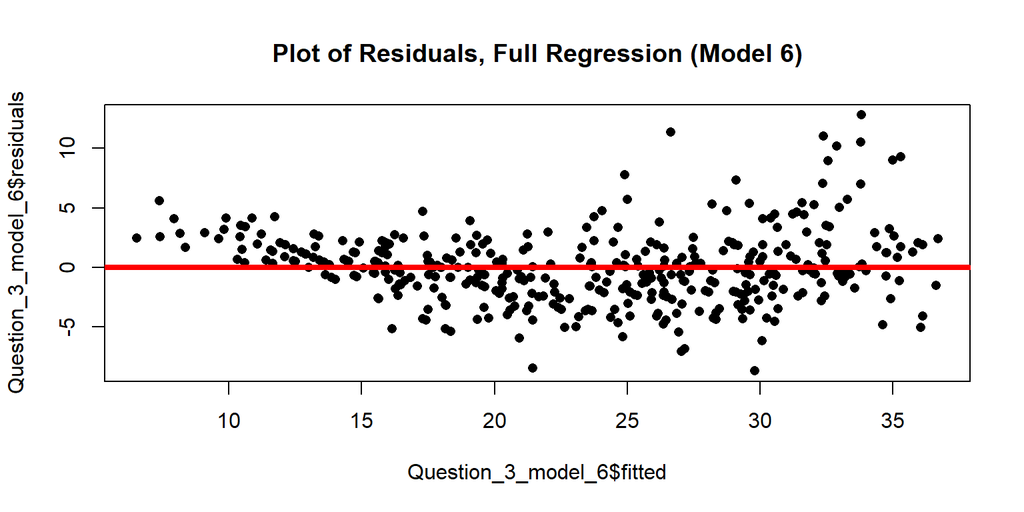

```r
# Generate residual plot.
plot(Question_3_model_6$fitted, Question_3_model_6$residuals,
     pch  = 16,
     main = "Plot of Residuals, Full Regression (Model 6)")
abline(h=0, lwd=4, col="red")
```

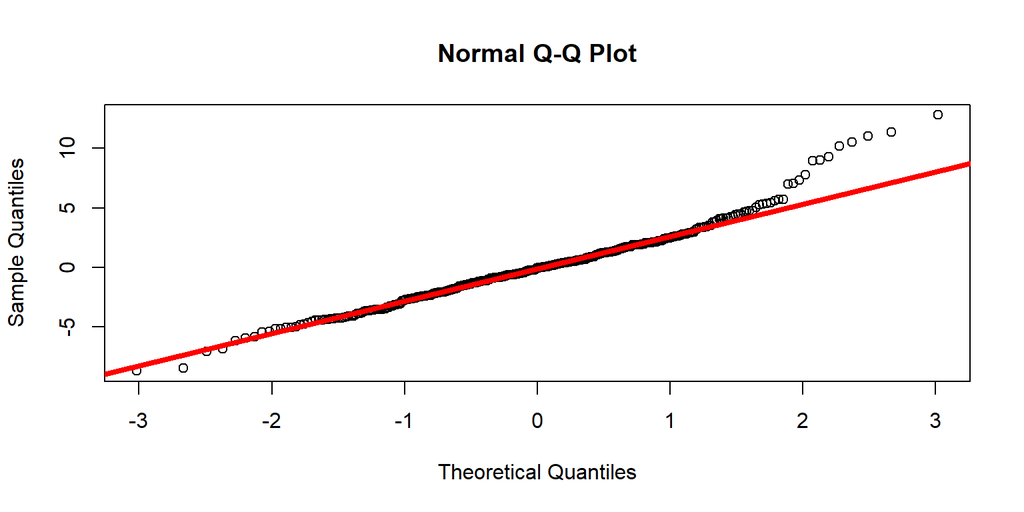

```r
# Generate QQ plots.
qqnorm(Question_3_model_6$residuals)
qqline(Question_3_model_6$residuals, lwd=4, col="red")
```

2. Summarize the effects found.

**Response:** Given the above attributes, we predict that the specified car will have a `mpg` equal to 18.6. At a 95% confidence level, the `mpg` of the car will fall between 16.1 and 21.2.

```r
# Create dataset to store information.
Question_3_car_x <- Question_3_clean
Question_3_car_x <- Question_3_clean[-c(2:nrow(Question_3_clean)),]
Question_3_car_x[1,] <- NA

# Set data to predict.
Question_3_car_x$cylinders[1] <- 8
Question_3_car_x$displacement[1] <- 350
Question_3_car_x$weight[1] <- 4000
Question_3_car_x$horsepower[1] <- 260
Question_3_car_x$year[1] <- 83
Question_3_car_x$origin[1] <- 1

# Predict mpg using provided data.
predict(Question_3_model_6,Question_3_car_x,se.fit=TRUE,interval = "confidence")
```

```
## $fit
##    fit  lwr  upr
## 1 18.6 16.1 21.2
##
## $se.fit
## [1] 1.3
##
## $df
## [1] 381
##
## $residual.scale
## [1] 3.09
```